# PRICE-OF-BULLDOZER

## **1. Problem Definition**

For this dataset, the problem we're trying to solve, or better, the question we're trying to answer is,

How well can we predict the future sale price of a bulldozer, given its characteristics previous examples of how much similar bulldozers have been sold for?

## **2. Data**

Looking at the dataset from Kaggle, you can you it's a time series problem. This means there's a time attribute to dataset.

In this case, it's historical sales data of bulldozers. Including things like, model type, size, sale date and more.

### **There are 3 datasets:**

- Train.csv - Historical bulldozer sales examples up to 2011 (close to 400,000 examples with 50+ different attributes, including SalePrice which is the target variable).
- Valid.csv - Historical bulldozer sales examples from January 1 2012 to April 30 2012 (close to 12,000 examples with the same attributes as Train.csv).
- Test.csv - Historical bulldozer sales examples from May 1 2012 to November 2012 (close to 12,000 examples but missing the SalePrice attribute, as this is what we'll be trying to predict).

## **3. Evaluation**

For this problem, Kaggle has set the evaluation metric to being root mean squared log error (RMSLE). As with many regression evaluations, the goal will be to get this value as low as possible.

To see how well our model is doing, we'll calculate the RMSLE and then compare our results to others on the Kaggle leaderboard.

## **4. Features**

Features are different parts of the data. During this step, you'll want to start finding out what you can about the data.

One of the most common ways to do this, is to create a data dictionary.

For this dataset, Kaggle provide a data dictionary which contains information about what each attribute of the dataset means. You can download this file directly from the Kaggle competition page (account required) or view it on Google Sheets.

With all of this being known, let's get started!

First, we'll import the dataset and start exploring. Since we know the evaluation metric we're trying to minimise, our first goal will be building a baseline model and seeing how it stacks up against the competition

```python
import pandas as pd
import numpy as np
import matplotlib.pyplot as plt
import seaborn as sns
import sklearn
```

```python
df= pd.read_csv("TrainAndValid.csv",low_memory=False)
df
```

|  | SalesID | SalePrice | MachineID | ModelID | datasource | auctioneerID | YearMade | MachineHoursCurrentMeter | UsageBand | saledate | ... | Undercarriage_Pad_Width | Stick_Length | Thumb | Pattern_Changer | Grouser_Type | Backhoe_Mounting | Blade_Type | Travel_Controls | Differential_Type | Steering_Controls |
| --- | --- | --- | --- | --- | --- | --- | --- | --- | --- | --- | --- | --- | --- | --- | --- | --- | --- | --- | --- | --- | --- |
| 0 | 1139246 | 66000.0 | 999089 | 3157 | 121 | 3.0 | 2004 | 68.0 | Low | 11/16/2006 0:00 | ... | NaN | NaN | NaN | NaN | NaN | NaN | NaN | NaN | Standard | Conventional |
| 1 | 1139248 | 57000.0 | 117657 | 77 | 121 | 3.0 | 1996 | 4640.0 | Low | 3/26/2004 0:00 | ... | NaN | NaN | NaN | NaN | NaN | NaN | NaN | NaN | Standard | Conventional |
| 2 | 1139249 | 10000.0 | 434808 | 7009 | 121 | 3.0 | 2001 | 2838.0 | High | 2/26/2004 0:00 | ... | NaN | NaN | NaN | NaN | NaN | NaN | NaN | NaN | NaN | NaN |
| 3 | 1139251 | 38500.0 | 1026470 | 332 | 121 | 3.0 | 2001 | 3486.0 | High | 5/19/2011 0:00 | ... | NaN | NaN | NaN | NaN | NaN | NaN | NaN | NaN | NaN | NaN |
| 4 | 1139253 | 11000.0 | 1057373 | 17311 | 121 | 3.0 | 2007 | 722.0 | Medium | 7/23/2009 0:00 | ... | NaN | NaN | NaN | NaN | NaN | NaN | NaN | NaN | NaN | NaN |
| ... | ... | ... | ... | ... | ... | ... | ... | ... | ... | ... | ... | ... | ... | ... | ... | ... | ... | ... | ... | ... | ... |
| 412693 | 6333344 | 10000.0 | 1919201 | 21435 | 149 | 2.0 | 2005 | NaN | NaN | 3/7/2012 0:00 | ... | None or Unspecified | None or Unspecified | None or Unspecified | None or Unspecified | Double | NaN | NaN | NaN | NaN | NaN |
| 412694 | 6333345 | 10500.0 | 1882122 | 21436 | 149 | 2.0 | 2005 | NaN | NaN | 1/28/2012 0:00 | ... | None or Unspecified | None or Unspecified | None or Unspecified | None or Unspecified | Double | NaN | NaN | NaN | NaN | NaN |
| 412695 | 6333347 | 12500.0 | 1944213 | 21435 | 149 | 2.0 | 2005 | NaN | NaN | 1/28/2012 0:00 | ... | None or Unspecified | None or Unspecified | None or Unspecified | None or Unspecified | Double | NaN | NaN | NaN | NaN | NaN |
| 412696 | 6333348 | 10000.0 | 1794518 | 21435 | 149 | 2.0 | 2006 | NaN | NaN | 3/7/2012 0:00 | ... | None or Unspecified | None or Unspecified | None or Unspecified | None or Unspecified | Double | NaN | NaN | NaN | NaN | NaN |
| 412697 | 6333349 | 13000.0 | 1944743 | 21436 | 149 | 2.0 | 2006 | NaN | NaN | 1/28/2012 0:00 | ... | None or Unspecified | None or Unspecified | None or Unspecified | None or Unspecified | Double | NaN | NaN | NaN | NaN | NaN |

412698 rows × 53 columns

```python
df.info()
```

```
<class 'pandas.core.frame.DataFrame'>
RangeIndex: 412698 entries, 0 to 412697
Data columns (total 53 columns):
 #   Column                    Non-Null Count   Dtype
---  ------                    --------------   -----
 0   SalesID                   412698 non-null  int64
 1   SalePrice                 412698 non-null  float64
 2   MachineID                 412698 non-null  int64
 3   ModelID                   412698 non-null  int64
 4   datasource                412698 non-null  int64
 5   auctioneerID              392562 non-null  float64
 6   YearMade                  412698 non-null  int64
 7   MachineHoursCurrentMeter  147504 non-null  float64
 8   UsageBand                 73670 non-null   object
 9   saledate                  412698 non-null  object
```

[output cut: 45 more lines]

```python
df.isnull().sum()
```

```
SalesID                          0
SalePrice                        0
MachineID                        0
ModelID                          0
datasource                       0
auctioneerID                 20136
YearMade                         0
MachineHoursCurrentMeter    265194
UsageBand                   339028
saledate                         0
fiModelDesc                      0
fiBaseModel                      0
fiSecondaryDesc             140727
fiModelSeries               354031
fiModelDescriptor           337882
ProductSize                 216605
fiProductClassDesc               0
state                            0
ProductGroup                     0
ProductGroupDesc                 0
Drive_System                305611
Enclosure                      334
Forks                       214983
Pad_Type                    331602
Ride_Control                259970
Stick                       331602
Transmission                224691
Turbocharged                331602
Blade_Extension             386715
Blade_Width                 386715
Enclosure_Type              386715
Engine_Horsepower           386715
Hydraulics                   82565
Pushblock                   386715
Ripper                      305753
Scarifier                   386704
Tip_Control                 386715
Tire_Size                   315060
Coupler                     192019
Coupler_System              367724
Grouser_Tracks              367823
Hydraulics_Flow             367823
Track_Type                  310505
Undercarriage_Pad_Width     309782
Stick_Length                310437
Thumb                       310366
Pattern_Changer             310437
Grouser_Type                310505
Backhoe_Mounting            331986
Blade_Type                  330823
Travel_Controls             330821
Differential_Type           341134
Steering_Controls           341176
dtype: int64
```

```python
df.columns
```

```
Index(['SalesID', 'SalePrice', 'MachineID', 'ModelID', 'datasource',
       'auctioneerID', 'YearMade', 'MachineHoursCurrentMeter', 'UsageBand',
       'saledate', 'fiModelDesc', 'fiBaseModel', 'fiSecondaryDesc',
       'fiModelSeries', 'fiModelDescriptor', 'ProductSize',
       'fiProductClassDesc', 'state', 'ProductGroup', 'ProductGroupDesc',
       'Drive_System', 'Enclosure', 'Forks', 'Pad_Type', 'Ride_Control',
       'Stick', 'Transmission', 'Turbocharged', 'Blade_Extension',
       'Blade_Width', 'Enclosure_Type', 'Engine_Horsepower', 'Hydraulics',
       'Pushblock', 'Ripper', 'Scarifier', 'Tip_Control', 'Tire_Size',
       'Coupler', 'Coupler_System', 'Grouser_Tracks', 'Hydraulics_Flow',
       'Track_Type', 'Undercarriage_Pad_Width', 'Stick_Length', 'Thumb',
       'Pattern_Changer', 'Grouser_Type', 'Backhoe_Mounting', 'Blade_Type',
       'Travel_Controls', 'Differential_Type', 'Steering_Controls'],
      dtype='object')
```

```python
df.saledate.dtype
```

```
dtype('O')
```

```python
df.saledate
```

```
0         11/16/2006 0:00
1          3/26/2004 0:00
2          2/26/2004 0:00
3          5/19/2011 0:00
4          7/23/2009 0:00
               ...
412693      3/7/2012 0:00
412694     1/28/2012 0:00
412695     1/28/2012 0:00
412696      3/7/2012 0:00
412697     1/28/2012 0:00
Name: saledate, Length: 412698, dtype: object
```

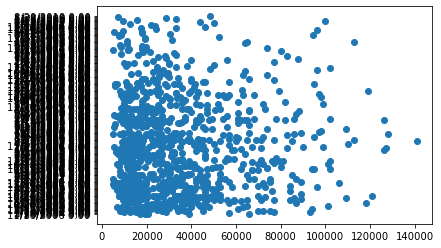

```python
fig,ax= plt.subplots()
ax.scatter(df["SalePrice"][:1000],df["saledate"][:1000],cmap=("r","g"))
```

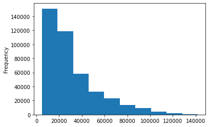

```python
df.SalePrice.plot.hist()
```

## Dealing with Times Series

### 1. Parsing date

when we are dealing with times series data, we want to enrich the date & time series as much as possible

We can do this by telling Pandas which of the columns has date in it using the "parse_dates" parameter.

```python
# Import the data again, but this time , parse date
df= pd.read_csv("TrainAndValid.csv", low_memory=False, parse_dates= ["saledate"])
df
```

|  | SalesID | SalePrice | MachineID | ModelID | datasource | auctioneerID | YearMade | MachineHoursCurrentMeter | UsageBand | saledate | ... | Undercarriage_Pad_Width | Stick_Length | Thumb | Pattern_Changer | Grouser_Type | Backhoe_Mounting | Blade_Type | Travel_Controls | Differential_Type | Steering_Controls |
| --- | --- | --- | --- | --- | --- | --- | --- | --- | --- | --- | --- | --- | --- | --- | --- | --- | --- | --- | --- | --- | --- |
| 0 | 1139246 | 66000.0 | 999089 | 3157 | 121 | 3.0 | 2004 | 68.0 | Low | 2006-11-16 | ... | NaN | NaN | NaN | NaN | NaN | NaN | NaN | NaN | Standard | Conventional |
| 1 | 1139248 | 57000.0 | 117657 | 77 | 121 | 3.0 | 1996 | 4640.0 | Low | 2004-03-26 | ... | NaN | NaN | NaN | NaN | NaN | NaN | NaN | NaN | Standard | Conventional |
| 2 | 1139249 | 10000.0 | 434808 | 7009 | 121 | 3.0 | 2001 | 2838.0 | High | 2004-02-26 | ... | NaN | NaN | NaN | NaN | NaN | NaN | NaN | NaN | NaN | NaN |
| 3 | 1139251 | 38500.0 | 1026470 | 332 | 121 | 3.0 | 2001 | 3486.0 | High | 2011-05-19 | ... | NaN | NaN | NaN | NaN | NaN | NaN | NaN | NaN | NaN | NaN |
| 4 | 1139253 | 11000.0 | 1057373 | 17311 | 121 | 3.0 | 2007 | 722.0 | Medium | 2009-07-23 | ... | NaN | NaN | NaN | NaN | NaN | NaN | NaN | NaN | NaN | NaN |
| ... | ... | ... | ... | ... | ... | ... | ... | ... | ... | ... | ... | ... | ... | ... | ... | ... | ... | ... | ... | ... | ... |
| 412693 | 6333344 | 10000.0 | 1919201 | 21435 | 149 | 2.0 | 2005 | NaN | NaN | 2012-03-07 | ... | None or Unspecified | None or Unspecified | None or Unspecified | None or Unspecified | Double | NaN | NaN | NaN | NaN | NaN |
| 412694 | 6333345 | 10500.0 | 1882122 | 21436 | 149 | 2.0 | 2005 | NaN | NaN | 2012-01-28 | ... | None or Unspecified | None or Unspecified | None or Unspecified | None or Unspecified | Double | NaN | NaN | NaN | NaN | NaN |
| 412695 | 6333347 | 12500.0 | 1944213 | 21435 | 149 | 2.0 | 2005 | NaN | NaN | 2012-01-28 | ... | None or Unspecified | None or Unspecified | None or Unspecified | None or Unspecified | Double | NaN | NaN | NaN | NaN | NaN |
| 412696 | 6333348 | 10000.0 | 1794518 | 21435 | 149 | 2.0 | 2006 | NaN | NaN | 2012-03-07 | ... | None or Unspecified | None or Unspecified | None or Unspecified | None or Unspecified | Double | NaN | NaN | NaN | NaN | NaN |
| 412697 | 6333349 | 13000.0 | 1944743 | 21436 | 149 | 2.0 | 2006 | NaN | NaN | 2012-01-28 | ... | None or Unspecified | None or Unspecified | None or Unspecified | None or Unspecified | Double | NaN | NaN | NaN | NaN | NaN |

412698 rows × 53 columns

```python
df.saledate.dtype
```

```
dtype('<M8[ns]')
```

```python
df.saledate[:1000]
```

```
0     2006-11-16
1     2004-03-26
2     2004-02-26
3     2011-05-19
4     2009-07-23
         ...
995   2009-07-16
996   2007-06-14
997   2005-09-22
998   2005-07-28
999   2011-06-16
Name: saledate, Length: 1000, dtype: datetime64[ns]
```

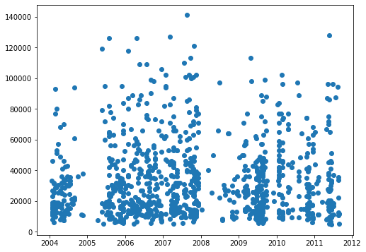

```python
fig,ax= plt.subplots(figsize=(8,6))
ax.scatter(df.saledate[:1000], df.SalePrice[:1000])
```

```python
df.saledate.head(20)
```

```
0    2006-11-16
1    2004-03-26
2    2004-02-26
3    2011-05-19
4    2009-07-23
5    2008-12-18
6    2004-08-26
7    2005-11-17
8    2009-08-27
9    2007-08-09
10   2008-08-21
11   2006-08-24
12   2005-10-20
13   2006-01-26
14   2006-01-03
15   2006-11-16
16   2007-06-14
17   2010-01-28
18   2006-03-09
19   2005-11-17
Name: saledate, dtype: datetime64[ns]
```

### Sort DataFrame by saledate

When working with time-series data, it is good practice to sort it by date

```python
df.sort_values(by=["saledate"], ascending=True, inplace=True)
df.saledate.head(20)
```

```
205615   1989-01-17
274835   1989-01-31
141296   1989-01-31
212552   1989-01-31
62755    1989-01-31
54653    1989-01-31
81383    1989-01-31
204924   1989-01-31
135376   1989-01-31
113390   1989-01-31
113394   1989-01-31
116419   1989-01-31
32138    1989-01-31
127610   1989-01-31
76171    1989-01-31
127000   1989-01-31
128130   1989-01-31
127626   1989-01-31
55455    1989-01-31
55454    1989-01-31
Name: saledate, dtype: datetime64[ns]
```

### Make A Copy Of The Original DataFrame

It is good practices to make a copy of the original dataframe, so that whatever we do on our copy won't affect the original dataframe

```python
# Make a copy
df_tmp= df.copy()
```

```python
df_tmp
```

|  | SalesID | SalePrice | MachineID | ModelID | datasource | auctioneerID | YearMade | MachineHoursCurrentMeter | UsageBand | saledate | ... | Undercarriage_Pad_Width | Stick_Length | Thumb | Pattern_Changer | Grouser_Type | Backhoe_Mounting | Blade_Type | Travel_Controls | Differential_Type | Steering_Controls |
| --- | --- | --- | --- | --- | --- | --- | --- | --- | --- | --- | --- | --- | --- | --- | --- | --- | --- | --- | --- | --- | --- |
| 0 | 1139246 | 66000.0 | 999089 | 3157 | 121 | 3.0 | 2004 | 68.0 | Low | 2006-11-16 | ... | NaN | NaN | NaN | NaN | NaN | NaN | NaN | NaN | Standard | Conventional |
| 1 | 1139248 | 57000.0 | 117657 | 77 | 121 | 3.0 | 1996 | 4640.0 | Low | 2004-03-26 | ... | NaN | NaN | NaN | NaN | NaN | NaN | NaN | NaN | Standard | Conventional |
| 2 | 1139249 | 10000.0 | 434808 | 7009 | 121 | 3.0 | 2001 | 2838.0 | High | 2004-02-26 | ... | NaN | NaN | NaN | NaN | NaN | NaN | NaN | NaN | NaN | NaN |
| 3 | 1139251 | 38500.0 | 1026470 | 332 | 121 | 3.0 | 2001 | 3486.0 | High | 2011-05-19 | ... | NaN | NaN | NaN | NaN | NaN | NaN | NaN | NaN | NaN | NaN |
| 4 | 1139253 | 11000.0 | 1057373 | 17311 | 121 | 3.0 | 2007 | 722.0 | Medium | 2009-07-23 | ... | NaN | NaN | NaN | NaN | NaN | NaN | NaN | NaN | NaN | NaN |
| ... | ... | ... | ... | ... | ... | ... | ... | ... | ... | ... | ... | ... | ... | ... | ... | ... | ... | ... | ... | ... | ... |
| 412693 | 6333344 | 10000.0 | 1919201 | 21435 | 149 | 2.0 | 2005 | NaN | NaN | 2012-03-07 | ... | None or Unspecified | None or Unspecified | None or Unspecified | None or Unspecified | Double | NaN | NaN | NaN | NaN | NaN |
| 412694 | 6333345 | 10500.0 | 1882122 | 21436 | 149 | 2.0 | 2005 | NaN | NaN | 2012-01-28 | ... | None or Unspecified | None or Unspecified | None or Unspecified | None or Unspecified | Double | NaN | NaN | NaN | NaN | NaN |
| 412695 | 6333347 | 12500.0 | 1944213 | 21435 | 149 | 2.0 | 2005 | NaN | NaN | 2012-01-28 | ... | None or Unspecified | None or Unspecified | None or Unspecified | None or Unspecified | Double | NaN | NaN | NaN | NaN | NaN |
| 412696 | 6333348 | 10000.0 | 1794518 | 21435 | 149 | 2.0 | 2006 | NaN | NaN | 2012-03-07 | ... | None or Unspecified | None or Unspecified | None or Unspecified | None or Unspecified | Double | NaN | NaN | NaN | NaN | NaN |
| 412697 | 6333349 | 13000.0 | 1944743 | 21436 | 149 | 2.0 | 2006 | NaN | NaN | 2012-01-28 | ... | None or Unspecified | None or Unspecified | None or Unspecified | None or Unspecified | Double | NaN | NaN | NaN | NaN | NaN |

412698 rows × 53 columns

```python
df_tmp.head(20).T
```

|  | 0 | 1 | 2 | 3 | 4 | 5 | 6 | 7 | 8 | 9 | 10 | 11 | 12 | 13 | 14 | 15 | 16 | 17 | 18 | 19 |
| --- | --- | --- | --- | --- | --- | --- | --- | --- | --- | --- | --- | --- | --- | --- | --- | --- | --- | --- | --- | --- |
| SalesID | 1139246 | 1139248 | 1139249 | 1139251 | 1139253 | 1139255 | 1139256 | 1139261 | 1139272 | 1139275 | 1139278 | 1139282 | 1139283 | 1139284 | 1139290 | 1139291 | 1139292 | 1139299 | 1139301 | 1139304 |
| SalePrice | 66000.0 | 57000.0 | 10000.0 | 38500.0 | 11000.0 | 26500.0 | 21000.0 | 27000.0 | 21500.0 | 65000.0 | 24000.0 | 22500.0 | 36000.0 | 30500.0 | 28000.0 | 19000.0 | 13500.0 | 9500.0 | 12500.0 | 11500.0 |
| MachineID | 999089 | 117657 | 434808 | 1026470 | 1057373 | 1001274 | 772701 | 902002 | 1036251 | 1016474 | 1024998 | 319906 | 1052214 | 1068082 | 1058450 | 1004810 | 1026973 | 1002713 | 125790 | 1011914 |
| ModelID | 3157 | 77 | 7009 | 332 | 17311 | 4605 | 1937 | 3539 | 36003 | 3883 | 4605 | 5255 | 2232 | 3542 | 5162 | 4604 | 9510 | 21442 | 7040 | 3177 |
| datasource | 121 | 121 | 121 | 121 | 121 | 121 | 121 | 121 | 121 | 121 | 121 | 121 | 121 | 121 | 121 | 121 | 121 | 121 | 121 | 121 |
| auctioneerID | 3.0 | 3.0 | 3.0 | 3.0 | 3.0 | 3.0 | 3.0 | 3.0 | 3.0 | 3.0 | 3.0 | 3.0 | 3.0 | 3.0 | 3.0 | 3.0 | 3.0 | 3.0 | 3.0 | 3.0 |
| YearMade | 2004 | 1996 | 2001 | 2001 | 2007 | 2004 | 1993 | 2001 | 2008 | 1000 | 2004 | 1998 | 1998 | 2001 | 2004 | 1999 | 1999 | 2003 | 2001 | 1991 |
| MachineHoursCurrentMeter | 68.0 | 4640.0 | 2838.0 | 3486.0 | 722.0 | 508.0 | 11540.0 | 4883.0 | 302.0 | 20700.0 | 1414.0 | 2764.0 | 0.0 | 1921.0 | 320.0 | 2450.0 | 1972.0 | 0.0 | 994.0 | 8005.0 |
| UsageBand | Low | Low | High | High | Medium | Low | High | High | Low | Medium | Medium | Low | NaN | Medium | Low | Medium | Low | NaN | Low | Medium |
| saledate | 2006-11-16 00:00:00 | 2004-03-26 00:00:00 | 2004-02-26 00:00:00 | 2011-05-19 00:00:00 | 2009-07-23 00:00:00 | 2008-12-18 00:00:00 | 2004-08-26 00:00:00 | 2005-11-17 00:00:00 | 2009-08-27 00:00:00 | 2007-08-09 00:00:00 | 2008-08-21 00:00:00 | 2006-08-24 00:00:00 | 2005-10-20 00:00:00 | 2006-01-26 00:00:00 | 2006-01-03 00:00:00 | 2006-11-16 00:00:00 | 2007-06-14 00:00:00 | 2010-01-28 00:00:00 | 2006-03-09 00:00:00 | 2005-11-17 00:00:00 |
| fiModelDesc | 521D | 950FII | 226 | PC120-6E | S175 | 310G | 790ELC | 416D | 430HAG | 988B | 310G | D31E | PC200LC6 | 420D | 214E | 310E | 334 | 45NX | 302.5 | 580SUPER K |
| fiBaseModel | 521 | 950 | 226 | PC120 | S175 | 310 | 790 | 416 | 430 | 988 | 310 | D31 | PC200 | 420 | 214 | 310 | 334 | 45 | 302.5 | 580 |
| fiSecondaryDesc | D | F | NaN | NaN | NaN | G | E | D | HAG | B | G | E | NaN | D | E | E | NaN | NX | NaN | SUPER K |
| fiModelSeries | NaN | II | NaN | -6E | NaN | NaN | NaN | NaN | NaN | NaN | NaN | NaN | LC | NaN | NaN | NaN | NaN | NaN | NaN | NaN |
| fiModelDescriptor | NaN | NaN | NaN | NaN | NaN | NaN | LC | NaN | NaN | NaN | NaN | NaN | 6 | NaN | NaN | NaN | NaN | NaN | NaN | NaN |
| ProductSize | NaN | Medium | NaN | Small | NaN | NaN | Large / Medium | NaN | Mini | Large | NaN | NaN | Large / Medium | NaN | NaN | NaN | Mini | Mini | Mini | NaN |
| fiProductClassDesc | Wheel Loader - 110.0 to 120.0 Horsepower | Wheel Loader - 150.0 to 175.0 Horsepower | Skid Steer Loader - 1351.0 to 1601.0 Lb Operat... | Hydraulic Excavator, Track - 12.0 to 14.0 Metr... | Skid Steer Loader - 1601.0 to 1751.0 Lb Operat... | Backhoe Loader - 14.0 to 15.0 Ft Standard Digg... | Hydraulic Excavator, Track - 21.0 to 24.0 Metr... | Backhoe Loader - 14.0 to 15.0 Ft Standard Digg... | Hydraulic Excavator, Track - 3.0 to 4.0 Metric... | Wheel Loader - 350.0 to 500.0 Horsepower | Backhoe Loader - 14.0 to 15.0 Ft Standard Digg... | Track Type Tractor, Dozer - 20.0 to 75.0 Horse... | Hydraulic Excavator, Track - 19.0 to 21.0 Metr... | Backhoe Loader - 14.0 to 15.0 Ft Standard Digg... | Backhoe Loader - 14.0 to 15.0 Ft Standard Digg... | Backhoe Loader - 14.0 to 15.0 Ft Standard Digg... | Hydraulic Excavator, Track - 3.0 to 4.0 Metric... | Hydraulic Excavator, Track - 4.0 to 5.0 Metric... | Hydraulic Excavator, Track - 2.0 to 3.0 Metric... | Backhoe Loader - 14.0 to 15.0 Ft Standard Digg... |
| state | Alabama | North Carolina | New York | Texas | New York | Arizona | Florida | Illinois | Texas | Florida | Oregon | Ohio | Ohio | Texas | North Carolina | Arkansas | Florida | Wisconsin | North Carolina | Illinois |
| ProductGroup | WL | WL | SSL | TEX | SSL | BL | TEX | BL | TEX | WL | BL | TTT | TEX | BL | BL | BL | TEX | TEX | TEX | BL |
| ProductGroupDesc | Wheel Loader | Wheel Loader | Skid Steer Loaders | Track Excavators | Skid Steer Loaders | Backhoe Loaders | Track Excavators | Backhoe Loaders | Track Excavators | Wheel Loader | Backhoe Loaders | Track Type Tractors | Track Excavators | Backhoe Loaders | Backhoe Loaders | Backhoe Loaders | Track Excavators | Track Excavators | Track Excavators | Backhoe Loaders |
| Drive_System | NaN | NaN | NaN | NaN | NaN | Four Wheel Drive | NaN | Four Wheel Drive | NaN | NaN | Four Wheel Drive | NaN | NaN | Four Wheel Drive | Four Wheel Drive | Two Wheel Drive | NaN | NaN | NaN | Two Wheel Drive |
| Enclosure | EROPS w AC | EROPS w AC | OROPS | EROPS w AC | EROPS | OROPS | EROPS | OROPS | EROPS | EROPS w AC | OROPS | EROPS w AC | EROPS | OROPS | OROPS | OROPS | EROPS | EROPS | EROPS | EROPS |
| Forks | None or Unspecified | None or Unspecified | None or Unspecified | NaN | None or Unspecified | None or Unspecified | NaN | None or Unspecified | NaN | None or Unspecified | None or Unspecified | NaN | NaN | None or Unspecified | None or Unspecified | None or Unspecified | NaN | NaN | NaN | None or Unspecified |
| Pad_Type | NaN | NaN | NaN | NaN | NaN | None or Unspecified | NaN | Reversible | NaN | NaN | Street | NaN | NaN | None or Unspecified | None or Unspecified | None or Unspecified | NaN | NaN | NaN | None or Unspecified |
| Ride_Control | None or Unspecified | None or Unspecified | NaN | NaN | NaN | No | NaN | No | NaN | None or Unspecified | No | NaN | NaN | No | No | No | NaN | NaN | NaN | No |
| Stick | NaN | NaN | NaN | NaN | NaN | Extended | NaN | Standard | NaN | NaN | Standard | NaN | NaN | Standard | Standard | Standard | NaN | NaN | NaN | Standard |
| Transmission | NaN | NaN | NaN | NaN | NaN | Powershuttle | NaN | Standard | NaN | NaN | Standard | Standard | NaN | Standard | Standard | Standard | NaN | NaN | NaN | Standard |
| Turbocharged | NaN | NaN | NaN | NaN | NaN | None or Unspecified | NaN | Yes | NaN | NaN | None or Unspecified | NaN | NaN | None or Unspecified | None or Unspecified | None or Unspecified | NaN | NaN | NaN | None or Unspecified |
| Blade_Extension | NaN | NaN | NaN | NaN | NaN | NaN | NaN | NaN | NaN | NaN | NaN | NaN | NaN | NaN | NaN | NaN | NaN | NaN | NaN | NaN |
| Blade_Width | NaN | NaN | NaN | NaN | NaN | NaN | NaN | NaN | NaN | NaN | NaN | NaN | NaN | NaN | NaN | NaN | NaN | NaN | NaN | NaN |
| Enclosure_Type | NaN | NaN | NaN | NaN | NaN | NaN | NaN | NaN | NaN | NaN | NaN | NaN | NaN | NaN | NaN | NaN | NaN | NaN | NaN | NaN |
| Engine_Horsepower | NaN | NaN | NaN | NaN | NaN | NaN | NaN | NaN | NaN | NaN | NaN | NaN | NaN | NaN | NaN | NaN | NaN | NaN | NaN | NaN |
| Hydraulics | 2 Valve | 2 Valve | Auxiliary | 2 Valve | Auxiliary | NaN | Standard | NaN | Auxiliary | 2 Valve | NaN | 2 Valve | Auxiliary | NaN | NaN | NaN | Auxiliary | Auxiliary | Auxiliary | NaN |
| Pushblock | NaN | NaN | NaN | NaN | NaN | NaN | NaN | NaN | NaN | NaN | NaN | NaN | NaN | NaN | NaN | NaN | NaN | NaN | NaN | NaN |
| Ripper | NaN | NaN | NaN | NaN | NaN | NaN | NaN | NaN | NaN | NaN | NaN | None or Unspecified | NaN | NaN | NaN | NaN | NaN | NaN | NaN | NaN |
| Scarifier | NaN | NaN | NaN | NaN | NaN | NaN | NaN | NaN | NaN | NaN | NaN | NaN | NaN | NaN | NaN | NaN | NaN | NaN | NaN | NaN |
| Tip_Control | NaN | NaN | NaN | NaN | NaN | NaN | NaN | NaN | NaN | NaN | NaN | NaN | NaN | NaN | NaN | NaN | NaN | NaN | NaN | NaN |
| Tire_Size | None or Unspecified | 23.5 | NaN | NaN | NaN | NaN | NaN | NaN | NaN | None or Unspecified | NaN | NaN | NaN | NaN | NaN | NaN | NaN | NaN | NaN | NaN |
| Coupler | None or Unspecified | None or Unspecified | None or Unspecified | None or Unspecified | None or Unspecified | NaN | None or Unspecified | NaN | Manual | None or Unspecified | NaN | NaN | None or Unspecified | NaN | NaN | NaN | None or Unspecified | None or Unspecified | None or Unspecified | NaN |
| Coupler_System | NaN | NaN | None or Unspecified | NaN | None or Unspecified | NaN | NaN | NaN | NaN | NaN | NaN | NaN | NaN | NaN | NaN | NaN | NaN | NaN | NaN | NaN |
| Grouser_Tracks | NaN | NaN | None or Unspecified | NaN | None or Unspecified | NaN | NaN | NaN | NaN | NaN | NaN | NaN | NaN | NaN | NaN | NaN | NaN | NaN | NaN | NaN |
| Hydraulics_Flow | NaN | NaN | Standard | NaN | Standard | NaN | NaN | NaN | NaN | NaN | NaN | NaN | NaN | NaN | NaN | NaN | NaN | NaN | NaN | NaN |
| Track_Type | NaN | NaN | NaN | NaN | NaN | NaN | Steel | NaN | Rubber | NaN | NaN | NaN | Steel | NaN | NaN | NaN | Rubber | Steel | Rubber | NaN |
| Undercarriage_Pad_Width | NaN | NaN | NaN | NaN | NaN | NaN | None or Unspecified | NaN | None or Unspecified | NaN | NaN | NaN | None or Unspecified | NaN | NaN | NaN | None or Unspecified | 16 inch | None or Unspecified | NaN |
| Stick_Length | NaN | NaN | NaN | NaN | NaN | NaN | None or Unspecified | NaN | None or Unspecified | NaN | NaN | NaN | 11' 0" | NaN | NaN | NaN | None or Unspecified | None or Unspecified | None or Unspecified | NaN |
| Thumb | NaN | NaN | NaN | NaN | NaN | NaN | None or Unspecified | NaN | None or Unspecified | NaN | NaN | NaN | None or Unspecified | NaN | NaN | NaN | None or Unspecified | None or Unspecified | None or Unspecified | NaN |
| Pattern_Changer | NaN | NaN | NaN | NaN | NaN | NaN | None or Unspecified | NaN | None or Unspecified | NaN | NaN | NaN | None or Unspecified | NaN | NaN | NaN | None or Unspecified | None or Unspecified | Yes | NaN |
| Grouser_Type | NaN | NaN | NaN | NaN | NaN | NaN | Double | NaN | Double | NaN | NaN | NaN | Double | NaN | NaN | NaN | Double | Double | Double | NaN |
| Backhoe_Mounting | NaN | NaN | NaN | NaN | NaN | NaN | NaN | NaN | NaN | NaN | NaN | None or Unspecified | NaN | NaN | NaN | NaN | NaN | NaN | NaN | NaN |
| Blade_Type | NaN | NaN | NaN | NaN | NaN | NaN | NaN | NaN | NaN | NaN | NaN | PAT | NaN | NaN | NaN | NaN | NaN | NaN | NaN | NaN |
| Travel_Controls | NaN | NaN | NaN | NaN | NaN | NaN | NaN | NaN | NaN | NaN | NaN | None or Unspecified | NaN | NaN | NaN | NaN | NaN | NaN | NaN | NaN |
| Differential_Type | Standard | Standard | NaN | NaN | NaN | NaN | NaN | NaN | NaN | Standard | NaN | NaN | NaN | NaN | NaN | NaN | NaN | NaN | NaN | NaN |
| Steering_Controls | Conventional | Conventional | NaN | NaN | NaN | NaN | NaN | NaN | NaN | Conventional | NaN | NaN | NaN | NaN | NaN | NaN | NaN | NaN | NaN | NaN |

### Add date time parameters for "saledate" column

check out the documentation: https://pandas.pydata.org/pandas-docs/version/0.23/generated/pandas.DatetimeIndex.html

```python
df_tmp["saleYear"]= df_tmp.saledate.dt.year
df_tmp["saleMonth"]= df_tmp.saledate.dt.month
df_tmp["saleDay"]= df_tmp.saledate.dt.day
df_tmp["saleDayOfWeek"]= df_tmp.saledate.dt.dayofweek
df_tmp["saleDayOfYear"]= df_tmp.saledate.dt.dayofyear
```

```python
df_tmp.head().T
```

|  | 0 | 1 | 2 | 3 | 4 |
| --- | --- | --- | --- | --- | --- |
| SalesID | 1139246 | 1139248 | 1139249 | 1139251 | 1139253 |
| SalePrice | 66000.0 | 57000.0 | 10000.0 | 38500.0 | 11000.0 |
| MachineID | 999089 | 117657 | 434808 | 1026470 | 1057373 |
| ModelID | 3157 | 77 | 7009 | 332 | 17311 |
| datasource | 121 | 121 | 121 | 121 | 121 |
| auctioneerID | 3.0 | 3.0 | 3.0 | 3.0 | 3.0 |
| YearMade | 2004 | 1996 | 2001 | 2001 | 2007 |
| MachineHoursCurrentMeter | 68.0 | 4640.0 | 2838.0 | 3486.0 | 722.0 |
| UsageBand | Low | Low | High | High | Medium |
| saledate | 2006-11-16 00:00:00 | 2004-03-26 00:00:00 | 2004-02-26 00:00:00 | 2011-05-19 00:00:00 | 2009-07-23 00:00:00 |
| fiModelDesc | 521D | 950FII | 226 | PC120-6E | S175 |
| fiBaseModel | 521 | 950 | 226 | PC120 | S175 |
| fiSecondaryDesc | D | F | NaN | NaN | NaN |
| fiModelSeries | NaN | II | NaN | -6E | NaN |
| fiModelDescriptor | NaN | NaN | NaN | NaN | NaN |
| ProductSize | NaN | Medium | NaN | Small | NaN |
| fiProductClassDesc | Wheel Loader - 110.0 to 120.0 Horsepower | Wheel Loader - 150.0 to 175.0 Horsepower | Skid Steer Loader - 1351.0 to 1601.0 Lb Operat... | Hydraulic Excavator, Track - 12.0 to 14.0 Metr... | Skid Steer Loader - 1601.0 to 1751.0 Lb Operat... |
| state | Alabama | North Carolina | New York | Texas | New York |
| ProductGroup | WL | WL | SSL | TEX | SSL |
| ProductGroupDesc | Wheel Loader | Wheel Loader | Skid Steer Loaders | Track Excavators | Skid Steer Loaders |
| Drive_System | NaN | NaN | NaN | NaN | NaN |
| Enclosure | EROPS w AC | EROPS w AC | OROPS | EROPS w AC | EROPS |
| Forks | None or Unspecified | None or Unspecified | None or Unspecified | NaN | None or Unspecified |
| Pad_Type | NaN | NaN | NaN | NaN | NaN |
| Ride_Control | None or Unspecified | None or Unspecified | NaN | NaN | NaN |
| Stick | NaN | NaN | NaN | NaN | NaN |
| Transmission | NaN | NaN | NaN | NaN | NaN |
| Turbocharged | NaN | NaN | NaN | NaN | NaN |
| Blade_Extension | NaN | NaN | NaN | NaN | NaN |
| Blade_Width | NaN | NaN | NaN | NaN | NaN |
| Enclosure_Type | NaN | NaN | NaN | NaN | NaN |
| Engine_Horsepower | NaN | NaN | NaN | NaN | NaN |
| Hydraulics | 2 Valve | 2 Valve | Auxiliary | 2 Valve | Auxiliary |
| Pushblock | NaN | NaN | NaN | NaN | NaN |
| Ripper | NaN | NaN | NaN | NaN | NaN |
| Scarifier | NaN | NaN | NaN | NaN | NaN |
| Tip_Control | NaN | NaN | NaN | NaN | NaN |
| Tire_Size | None or Unspecified | 23.5 | NaN | NaN | NaN |
| Coupler | None or Unspecified | None or Unspecified | None or Unspecified | None or Unspecified | None or Unspecified |
| Coupler_System | NaN | NaN | None or Unspecified | NaN | None or Unspecified |
| Grouser_Tracks | NaN | NaN | None or Unspecified | NaN | None or Unspecified |
| Hydraulics_Flow | NaN | NaN | Standard | NaN | Standard |
| Track_Type | NaN | NaN | NaN | NaN | NaN |
| Undercarriage_Pad_Width | NaN | NaN | NaN | NaN | NaN |
| Stick_Length | NaN | NaN | NaN | NaN | NaN |
| Thumb | NaN | NaN | NaN | NaN | NaN |
| Pattern_Changer | NaN | NaN | NaN | NaN | NaN |
| Grouser_Type | NaN | NaN | NaN | NaN | NaN |
| Backhoe_Mounting | NaN | NaN | NaN | NaN | NaN |
| Blade_Type | NaN | NaN | NaN | NaN | NaN |
| Travel_Controls | NaN | NaN | NaN | NaN | NaN |
| Differential_Type | Standard | Standard | NaN | NaN | NaN |
| Steering_Controls | Conventional | Conventional | NaN | NaN | NaN |
| saleYear | 2006 | 2004 | 2004 | 2011 | 2009 |
| saleMonth | 11 | 3 | 2 | 5 | 7 |
| saleDay | 16 | 26 | 26 | 19 | 23 |
| saleDayOfWeek | 3 | 4 | 3 | 3 | 3 |
| saleDayOfYear | 320 | 86 | 57 | 139 | 204 |

```python
# Now we've enriched our DataFrame with date time features, we can now remove "saledate"
df_tmp.drop("saledate",axis=1, inplace=True)
```

```python
df_tmp.state.value_counts()
```

```
Florida           67320
Texas             53110
California        29761
Washington        16222
Georgia           14633
Maryland          13322
Mississippi       13240
Ohio              12369
Illinois          11540
Colorado          11529
New Jersey        11156
North Carolina    10636
Tennessee         10298
Alabama           10292
Pennsylvania      10234
South Carolina     9951
Arizona            9364
New York           8639
Connecticut        8276
Minnesota          7885
Missouri           7178
Nevada             6932
Louisiana          6627
Kentucky           5351
Maine              5096
Indiana            4124
Arkansas           3933
New Mexico         3631
Utah               3046
Unspecified        2801
Wisconsin          2745
New Hampshire      2738
Virginia           2353
Idaho              2025
Oregon             1911
Michigan           1831
Wyoming            1672
Montana            1336
Iowa               1336
Oklahoma           1326
Nebraska            866
West Virginia       840
Kansas              667
Delaware            510
North Dakota        480
Alaska              430
Massachusetts       347
Vermont             300
South Dakota        244
Hawaii              118
Rhode Island         83
Puerto Rico          42
Washington DC         2
Name: state, dtype: int64
```

```python
df_tmp.info()
```

```
<class 'pandas.core.frame.DataFrame'>
Int64Index: 412698 entries, 205615 to 409203
Data columns (total 57 columns):
 #   Column                    Non-Null Count   Dtype
---  ------                    --------------   -----
 0   SalesID                   412698 non-null  int64
 1   SalePrice                 412698 non-null  float64
 2   MachineID                 412698 non-null  int64
 3   ModelID                   412698 non-null  int64
 4   datasource                412698 non-null  int64
 5   auctioneerID              392562 non-null  float64
 6   YearMade                  412698 non-null  int64
 7   MachineHoursCurrentMeter  147504 non-null  float64
 8   UsageBand                 73670 non-null   object
 9   fiModelDesc               412698 non-null  object
```

[output cut: 49 more lines]

### Covert String to Categories

One way we can turn all of our data into numbers is by converting them into pandas categories.

We can check the different dtype compatible with pandas here:

https://pandas.pydata.org/pandas-docs/version/0.25/reference/general_utility_functions.html#data-types-related-functionality

```python
df_tmp.head().T
```

|  | 205615 | 274835 | 141296 | 212552 | 62755 |
| --- | --- | --- | --- | --- | --- |
| SalesID | 1646770 | 1821514 | 1505138 | 1671174 | 1329056 |
| SalePrice | 9500.0 | 14000.0 | 50000.0 | 16000.0 | 22000.0 |
| MachineID | 1126363 | 1194089 | 1473654 | 1327630 | 1336053 |
| ModelID | 8434 | 10150 | 4139 | 8591 | 4089 |
| datasource | 132 | 132 | 132 | 132 | 132 |
| auctioneerID | 18.0 | 99.0 | 99.0 | 99.0 | 99.0 |
| YearMade | 1974 | 1980 | 1978 | 1980 | 1984 |
| MachineHoursCurrentMeter | NaN | NaN | NaN | NaN | NaN |
| UsageBand | NaN | NaN | NaN | NaN | NaN |
| fiModelDesc | TD20 | A66 | D7G | A62 | D3B |
| fiBaseModel | TD20 | A66 | D7 | A62 | D3 |
| fiSecondaryDesc | NaN | NaN | G | NaN | B |
| fiModelSeries | NaN | NaN | NaN | NaN | NaN |
| fiModelDescriptor | NaN | NaN | NaN | NaN | NaN |
| ProductSize | Medium | NaN | Large | NaN | NaN |
| fiProductClassDesc | Track Type Tractor, Dozer - 105.0 to 130.0 Hor... | Wheel Loader - 120.0 to 135.0 Horsepower | Track Type Tractor, Dozer - 190.0 to 260.0 Hor... | Wheel Loader - Unidentified | Track Type Tractor, Dozer - 20.0 to 75.0 Horse... |
| state | Texas | Florida | Florida | Florida | Florida |
| ProductGroup | TTT | WL | TTT | WL | TTT |
| ProductGroupDesc | Track Type Tractors | Wheel Loader | Track Type Tractors | Wheel Loader | Track Type Tractors |
| Drive_System | NaN | NaN | NaN | NaN | NaN |
| Enclosure | OROPS | OROPS | OROPS | EROPS | OROPS |
| Forks | NaN | None or Unspecified | NaN | None or Unspecified | NaN |
| Pad_Type | NaN | NaN | NaN | NaN | NaN |
| Ride_Control | NaN | None or Unspecified | NaN | None or Unspecified | NaN |
| Stick | NaN | NaN | NaN | NaN | NaN |
| Transmission | Direct Drive | NaN | Standard | NaN | Standard |
| Turbocharged | NaN | NaN | NaN | NaN | NaN |
| Blade_Extension | NaN | NaN | NaN | NaN | NaN |
| Blade_Width | NaN | NaN | NaN | NaN | NaN |
| Enclosure_Type | NaN | NaN | NaN | NaN | NaN |
| Engine_Horsepower | NaN | NaN | NaN | NaN | NaN |
| Hydraulics | 2 Valve | 2 Valve | 2 Valve | 2 Valve | 2 Valve |
| Pushblock | NaN | NaN | NaN | NaN | NaN |
| Ripper | None or Unspecified | NaN | None or Unspecified | NaN | None or Unspecified |
| Scarifier | NaN | NaN | NaN | NaN | NaN |
| Tip_Control | NaN | NaN | NaN | NaN | NaN |
| Tire_Size | NaN | None or Unspecified | NaN | None or Unspecified | NaN |
| Coupler | NaN | None or Unspecified | NaN | None or Unspecified | NaN |
| Coupler_System | NaN | NaN | NaN | NaN | NaN |
| Grouser_Tracks | NaN | NaN | NaN | NaN | NaN |
| Hydraulics_Flow | NaN | NaN | NaN | NaN | NaN |
| Track_Type | NaN | NaN | NaN | NaN | NaN |
| Undercarriage_Pad_Width | NaN | NaN | NaN | NaN | NaN |
| Stick_Length | NaN | NaN | NaN | NaN | NaN |
| Thumb | NaN | NaN | NaN | NaN | NaN |
| Pattern_Changer | NaN | NaN | NaN | NaN | NaN |
| Grouser_Type | NaN | NaN | NaN | NaN | NaN |
| Backhoe_Mounting | None or Unspecified | NaN | None or Unspecified | NaN | None or Unspecified |
| Blade_Type | Straight | NaN | Straight | NaN | PAT |
| Travel_Controls | None or Unspecified | NaN | None or Unspecified | NaN | Lever |
| Differential_Type | NaN | Standard | NaN | Standard | NaN |
| Steering_Controls | NaN | Conventional | NaN | Conventional | NaN |
| saleYear | 1989 | 1989 | 1989 | 1989 | 1989 |
| saleMonth | 1 | 1 | 1 | 1 | 1 |
| saleDay | 17 | 31 | 31 | 31 | 31 |
| saleDayOfWeek | 1 | 1 | 1 | 1 | 1 |
| saleDayOfYear | 17 | 31 | 31 | 31 | 31 |

```python
# To check if What kind of datatype you are working with
pd.api.types.is_string_dtype(df_tmp["UsageBand"])
```

```
True
```

```python
# Find the columns which contains strings
for label,content in df_tmp.items():
    if pd.api.types.is_string_dtype(content):
        print(label)
```

```
UsageBand
fiModelDesc
fiBaseModel
fiSecondaryDesc
fiModelSeries
fiModelDescriptor
ProductSize
fiProductClassDesc
state
ProductGroup
ProductGroupDesc
Drive_System
Enclosure
Forks
Pad_Type
Ride_Control
Stick
Transmission
Turbocharged
Blade_Extension
Blade_Width
Enclosure_Type
Engine_Horsepower
Hydraulics
Pushblock
Ripper
Scarifier
Tip_Control
Tire_Size
Coupler
Coupler_System
Grouser_Tracks
Hydraulics_Flow
Track_Type
Undercarriage_Pad_Width
Stick_Length
Thumb
Pattern_Changer
Grouser_Type
Backhoe_Mounting
Blade_Type
Travel_Controls
Differential_Type
Steering_Controls
```

```python
#This will turn all string values into category values
for label,content in df_tmp.items():
    if pd.api.types.is_string_dtype(content):
        df_tmp[label]= content.astype("category").cat.as_ordered()
```

```python
df_tmp.info()
```

[output not shown]

[output cut: 50 more lines]

## Fill Missing Values

### Fill Numeric Missing Values First

```python
for label,content in df_tmp.items():
    if pd.api.types.is_numeric_dtype(content):
        print(label)
```

```
SalesID
SalePrice
MachineID
ModelID
datasource
auctioneerID
YearMade
MachineHoursCurrentMeter
saleYear
saleMonth
saleDay
saleDayOfWeek
saleDayOfYear
```

```python
# Check for whic numeric column has null values

for label,content in df_tmp.items():
    if pd.api.types.is_numeric_dtype(content):
        if pd.isnull(content).sum():
            print(label)
```

```
auctioneerID
MachineHoursCurrentMeter
```

```python
#Fill numeric rows with the median

for label,content in df_tmp.items():
    if pd.api.types.is_numeric_dtype(content):
        if pd.isnull(content).sum():
            #Add a binary content which tell us if the column was missing
            df_tmp[label+ "Missing_Data"]= pd.isnull(content)
            #Fill missing numeric values with Median
            df_tmp[label]= content.fillna(content.median())
```

```python
#Check if there are any null numeric value
for label,content in df_tmp.items():
    if pd.api.types.is_numeric_dtype(content):
        if pd.isnull(content).sum():
            print(label)
```

### Filling and Turning Categorical Variables into numbers

- WE CAN TURN CATEGORICAL VARIABLES INTO NUMBERS USING (.CODE)

```python
for label, content in df_tmp.items():
    if not pd.api.types.is_numeric_dtype(content):
        print(label)
```

```
UsageBand
fiModelDesc
fiBaseModel
fiSecondaryDesc
fiModelSeries
fiModelDescriptor
ProductSize
fiProductClassDesc
state
ProductGroup
ProductGroupDesc
Drive_System
Enclosure
Forks
Pad_Type
Ride_Control
Stick
Transmission
Turbocharged
Blade_Extension
Blade_Width
Enclosure_Type
Engine_Horsepower
Hydraulics
Pushblock
Ripper
Scarifier
Tip_Control
Tire_Size
Coupler
Coupler_System
Grouser_Tracks
Hydraulics_Flow
Track_Type
Undercarriage_Pad_Width
Stick_Length
Thumb
Pattern_Changer
Grouser_Type
Backhoe_Mounting
Blade_Type
Travel_Controls
Differential_Type
Steering_Controls
```

```python
#Check for non numeric data
for label,content in df_tmp.items():
    if not pd.api.types.is_numeric_dtype(content):
        if pd.isnull(content).sum():
            print(label)
```

```
UsageBand
fiSecondaryDesc
fiModelSeries
fiModelDescriptor
ProductSize
Drive_System
Enclosure
Forks
Pad_Type
Ride_Control
Stick
Transmission
Turbocharged
Blade_Extension
Blade_Width
Enclosure_Type
Engine_Horsepower
Hydraulics
Pushblock
Ripper
Scarifier
Tip_Control
Tire_Size
Coupler
Coupler_System
Grouser_Tracks
Hydraulics_Flow
Track_Type
Undercarriage_Pad_Width
Stick_Length
Thumb
Pattern_Changer
Grouser_Type
Backhoe_Mounting
Blade_Type
Travel_Controls
Differential_Type
Steering_Controls
```

```python
#Turn categorical data into numeric and fill missing values
for label,content in df_tmp.items():
    if not pd.api.types.is_numeric_dtype(content):
        #Addd binary column to indicate whether sample had missing values
        df_tmp[label+ "Is_missing"]= pd.isnull(content)
        # Tunr Categorical data into numbers and add +1
        df_tmp[label]= pd.Categorical(content).codes+1
```

```python
df_tmp.info()
```

```
<class 'pandas.core.frame.DataFrame'>
RangeIndex: 412698 entries, 0 to 412697
Columns: 149 entries, SalesID to Steering_ControlsIs_missing
dtypes: bool(92), float64(3), int16(4), int64(10), int8(40)
memory usage: 96.0 MB
```

```python
df_tmp.head().T
```

|  | 0 | 1 | 2 | 3 | 4 |
| --- | --- | --- | --- | --- | --- |
| SalesID | 1139246 | 1139248 | 1139249 | 1139251 | 1139253 |
| SalePrice | 66000.0 | 57000.0 | 10000.0 | 38500.0 | 11000.0 |
| MachineID | 999089 | 117657 | 434808 | 1026470 | 1057373 |
| ModelID | 3157 | 77 | 7009 | 332 | 17311 |
| datasource | 121 | 121 | 121 | 121 | 121 |
| ... | ... | ... | ... | ... | ... |
| Backhoe_MountingIs_missing | True | True | True | True | True |
| Blade_TypeIs_missing | True | True | True | True | True |
| Travel_ControlsIs_missing | True | True | True | True | True |
| Differential_TypeIs_missing | False | False | True | True | True |
| Steering_ControlsIs_missing | False | False | True | True | True |

149 rows × 5 columns

```python
df_tmp.isna().sum()
```

```
SalesID                        0
SalePrice                      0
MachineID                      0
ModelID                        0
datasource                     0
                              ..
Backhoe_MountingIs_missing     0
Blade_TypeIs_missing           0
Travel_ControlsIs_missing      0
Differential_TypeIs_missing    0
Steering_ControlsIs_missing    0
Length: 149, dtype: int64
```

```python
%%time

from sklearn.ensemble import RandomForestRegressor

#instantiate model
model= RandomForestRegressor(n_jobs=-1, random_state=42)

#Fit model
model.fit(df_tmp.drop("SalePrice",axis=1),df_tmp["SalePrice"] )
```

```
CPU times: total: 30min 1s
Wall time: 8min 47s
```

```
RandomForestRegressor(n_jobs=-1, random_state=42)
```

```python
#Score the model
model.score(df_tmp.drop("SalePrice",axis=1),df_tmp["SalePrice"] )
```

```
0.987550144377029
```

**Question:** Why doesn't the above metric hold water(why is it not reliable)

### Splitting Data into Training and Validation Set

Kaggle gave the validation set already, but we're going to create our own. Our validation set should be data from 2012 while our train set contains data from every other year except 2012

```python
df_tmp.saleYear.value_counts()
```

```
2009    43849
2008    39767
2011    35197
2010    33390
2007    32208
2006    21685
2005    20463
2004    19879
2001    17594
2000    17415
2002    17246
2003    15254
1998    13046
1999    12793
2012    11573
1997     9785
1996     8829
1995     8530
1994     7929
1993     6303
1992     5519
1991     5109
1989     4806
1990     4529
Name: saleYear, dtype: int64
```

```python
#Split into validation and train set
df_val= df_tmp[df_tmp.saleYear==2012]
df_train= df_tmp[df_tmp.saleYear != 2012]

len(df_val), len(df_train)
```

```
(11573, 401125)
```

```python
#Split data into X and Y
x_train,y_train= df_train.drop("SalePrice", axis=1), df_train.SalePrice
x_valid,y_valid= df_val.drop("SalePrice", axis=1), df_val.SalePrice

x_train.shape,y_train.shape,x_valid.shape,y_valid.shape
```

```
((401125, 148), (401125,), (11573, 148), (11573,))
```

### Building an Evaluation Function

```python
#Create an evaluation function
from sklearn.metrics import mean_squared_log_error, mean_absolute_error, r2_score

def rmsle(y_test, y_preds):
    """
    Calculate the mean squared log error between prediction and true labels
    """
    return np.sqrt(mean_squared_log_error(y_test,y_preds))

#Create function to evaluate metrics on a few more level
def show_scores(model):
    train_preds= model.predict(x_train)
    val_preds= model.predict(x_valid)

    score= {"Training MAE":mean_absolute_error(y_train,train_preds),
            "Valid MAE":mean_absolute_error(y_valid,val_preds),
            "Training RMSLE": mean_squared_log_error(y_train, train_preds),
            "Valid RMSLE": mean_squared_log_error(y_valid, val_preds),
            "Training r2": r2_score(y_train,train_preds),
            "Valid r2": r2_score(y_valid, val_preds)}
    return(score)
```

### Testing our model on a subset (to tune hyperparameter)

```python
# Our model is going to take too long to run because of the large amount of data, so we'll reduce the data
model= RandomForestRegressor(n_jobs=-1,
                             random_state=42,
                             max_samples=10000)
```

```python
%%time
#Cutting down the maximum number of samples can help fasten the run time
model.fit(x_train,y_train)
```

```
CPU times: total: 1min 27s
Wall time: 32.7 s
```

```
RandomForestRegressor(max_samples=10000, n_jobs=-1, random_state=42)
```

```python
show_scores(model)
```

```
{'Training MAE': 5551.885231860392,
 'Valid MAE': 7143.059586105591,
 'Training RMSLE': 0.06628094748199449,
 'Valid RMSLE': 0.08546347222620242,
 'Training r2': 0.8609502198295116,
 'Valid r2': 0.8332715810983576}
```

### Randomized SearchCV

```python
%%time
from sklearn.model_selection import RandomizedSearchCV

#Different RandomForest Hyperparameter
rf_grid= {"n_estimators":np.arange(10,100,10),
         "max_depth":[None,3,5,10],
         "min_samples_split":np.arange(2,20,2),
         "min_samples_leaf":np.arange(1,20,2),
         "max_features":[0.5,1,"sqrt","auto"],
         "max_samples":[10000]}

#Instantiate RAndpmizedSearchCV model
rs_model= RandomizedSearchCV(RandomForestRegressor(n_jobs=-1,
                                                   random_state=42),
                            param_distributions=rf_grid,
                            n_iter=2,
                            cv=5,
                            verbose=True)
#Fit RandomizedSearchCV
rs_model.fit(x_train,y_train)
```

```
Fitting 5 folds for each of 2 candidates, totalling 10 fits
```

```
CPU times: total: 1min 8s
Wall time: 3min 13s
```

```
RandomizedSearchCV(cv=5,
                   estimator=RandomForestRegressor(n_jobs=-1, random_state=42),
                   n_iter=2,
                   param_distributions={'max_depth': [None, 3, 5, 10],
                                        'max_features': [0.5, 1, 'sqrt',
                                                         'auto'],
                                        'max_samples': [10000],
                                        'min_samples_leaf': array([ 1,  3,  5,  7,  9, 11, 13, 15, 17, 19]),
                                        'min_samples_split': array([ 2,  4,  6,  8, 10, 12, 14, 16, 18]),
                                        'n_estimators': array([10, 20, 30, 40, 50, 60, 70, 80, 90])},
                   verbose=True)
```

```python
rs_model.best_params_
```

```
{'n_estimators': 20,
 'min_samples_split': 2,
 'min_samples_leaf': 13,
 'max_samples': 10000,
 'max_features': 'auto',
 'max_depth': 10}
```

```python
show_scores(rs_model)
```

```
{'Training MAE': 6749.7833169545265,
 'Valid MAE': 8265.474471853617,
 'Training RMSLE': 0.09067018890096433,
 'Valid RMSLE': 0.1083052133574266,
 'Training r2': 0.7999779623787006,
 'Valid r2': 0.7713028711277398}
```

### Train a model with the best hyperparameters

**Note**: These parameters were gotten after 100 iterations of the RandomizedSearchCV

```python
%%time
#Most ideal hyperparameter
ideal_model= RandomForestRegressor(n_jobs=-1,
                                  n_estimators=40,
                                  min_samples_split=14,
                                  min_samples_leaf=1,
                                  max_features=0.5,
                                  max_samples=None,
                                  random_state=42)

#fit Model
ideal_model.fit(x_train,y_train)
```

```
CPU times: total: 5min 5s
Wall time: 1min 33s
```

[output not shown]

```python
show_scores(ideal_model)
```

```
{'Training MAE': 2953.1450802995564,
 'Valid MAE': 5969.8586758528445,
 'Training RMSLE': 0.020924803520354633,
 'Valid RMSLE': 0.06066059633685338,
 'Training r2': 0.9589479331157784,
 'Valid r2': 0.8812601397663162}
```

### Make predictions on the Test dataset

```python
df=pd.read_csv("Test.csv", parse_dates=["saledate"])
df.head()
```

|  | SalesID | MachineID | ModelID | datasource | auctioneerID | YearMade | MachineHoursCurrentMeter | UsageBand | saledate | fiModelDesc | ... | Undercarriage_Pad_Width | Stick_Length | Thumb | Pattern_Changer | Grouser_Type | Backhoe_Mounting | Blade_Type | Travel_Controls | Differential_Type | Steering_Controls |
| --- | --- | --- | --- | --- | --- | --- | --- | --- | --- | --- | --- | --- | --- | --- | --- | --- | --- | --- | --- | --- | --- |
| 0 | 1227829 | 1006309 | 3168 | 121 | 3 | 1999 | 3688.0 | Low | 2012-05-03 | 580G | ... | NaN | NaN | NaN | NaN | NaN | NaN | NaN | NaN | NaN | NaN |
| 1 | 1227844 | 1022817 | 7271 | 121 | 3 | 1000 | 28555.0 | High | 2012-05-10 | 936 | ... | NaN | NaN | NaN | NaN | NaN | NaN | NaN | NaN | Standard | Conventional |
| 2 | 1227847 | 1031560 | 22805 | 121 | 3 | 2004 | 6038.0 | Medium | 2012-05-10 | EC210BLC | ... | None or Unspecified | 9' 6" | Manual | None or Unspecified | Double | NaN | NaN | NaN | NaN | NaN |
| 3 | 1227848 | 56204 | 1269 | 121 | 3 | 2006 | 8940.0 | High | 2012-05-10 | 330CL | ... | None or Unspecified | None or Unspecified | Manual | Yes | Triple | NaN | NaN | NaN | NaN | NaN |
| 4 | 1227863 | 1053887 | 22312 | 121 | 3 | 2005 | 2286.0 | Low | 2012-05-10 | 650K | ... | NaN | NaN | NaN | NaN | NaN | None or Unspecified | PAT | None or Unspecified | NaN | NaN |

5 rows × 52 columns

```python
df1= df.copy()
```

```python
#Make prediction on the Test dataset
test_preds= ideal_model.predict(df1)
```

[output not shown]

### Preprocessing our data(making our test dataset in the same format as our training dataset)

```python
df1.head()
```

|  | SalesID | MachineID | ModelID | datasource | auctioneerID | YearMade | MachineHoursCurrentMeter | UsageBand | saledate | fiModelDesc | ... | Undercarriage_Pad_Width | Stick_Length | Thumb | Pattern_Changer | Grouser_Type | Backhoe_Mounting | Blade_Type | Travel_Controls | Differential_Type | Steering_Controls |
| --- | --- | --- | --- | --- | --- | --- | --- | --- | --- | --- | --- | --- | --- | --- | --- | --- | --- | --- | --- | --- | --- |
| 0 | 1227829 | 1006309 | 3168 | 121 | 3 | 1999 | 3688.0 | Low | 2012-05-03 | 580G | ... | NaN | NaN | NaN | NaN | NaN | NaN | NaN | NaN | NaN | NaN |
| 1 | 1227844 | 1022817 | 7271 | 121 | 3 | 1000 | 28555.0 | High | 2012-05-10 | 936 | ... | NaN | NaN | NaN | NaN | NaN | NaN | NaN | NaN | Standard | Conventional |
| 2 | 1227847 | 1031560 | 22805 | 121 | 3 | 2004 | 6038.0 | Medium | 2012-05-10 | EC210BLC | ... | None or Unspecified | 9' 6" | Manual | None or Unspecified | Double | NaN | NaN | NaN | NaN | NaN |
| 3 | 1227848 | 56204 | 1269 | 121 | 3 | 2006 | 8940.0 | High | 2012-05-10 | 330CL | ... | None or Unspecified | None or Unspecified | Manual | Yes | Triple | NaN | NaN | NaN | NaN | NaN |
| 4 | 1227863 | 1053887 | 22312 | 121 | 3 | 2005 | 2286.0 | Low | 2012-05-10 | 650K | ... | NaN | NaN | NaN | NaN | NaN | None or Unspecified | PAT | None or Unspecified | NaN | NaN |

5 rows × 52 columns

```python
df1["saleYear"]= df1.saledate.dt.year
df1["saleMonth"]= df1.saledate.dt.month
df1["saleDay"]= df1.saledate.dt.day
df1["saleDayOfWeek"]= df1.saledate.dt.dayofweek
df1["saleDayOfYear"]= df1.saledate.dt.dayofyear
```

```python
df1.drop("saledate",axis=1,inplace=True)
```

```python
df1.head().T
```

|  | 0 | 1 | 2 | 3 | 4 |
| --- | --- | --- | --- | --- | --- |
| SalesID | 1227829 | 1227844 | 1227847 | 1227848 | 1227863 |
| MachineID | 1006309 | 1022817 | 1031560 | 56204 | 1053887 |
| ModelID | 3168 | 7271 | 22805 | 1269 | 22312 |
| datasource | 121 | 121 | 121 | 121 | 121 |
| auctioneerID | 3 | 3 | 3 | 3 | 3 |
| YearMade | 1999 | 1000 | 2004 | 2006 | 2005 |
| MachineHoursCurrentMeter | 3688.0 | 28555.0 | 6038.0 | 8940.0 | 2286.0 |
| UsageBand | Low | High | Medium | High | Low |
| fiModelDesc | 580G | 936 | EC210BLC | 330CL | 650K |
| fiBaseModel | 580 | 936 | EC210 | 330 | 650 |
| fiSecondaryDesc | G | NaN | B | C | K |
| fiModelSeries | NaN | NaN | NaN | NaN | NaN |
| fiModelDescriptor | NaN | NaN | LC | L | NaN |
| ProductSize | NaN | Medium | Large / Medium | Large / Medium | NaN |
| fiProductClassDesc | Backhoe Loader - 14.0 to 15.0 Ft Standard Digg... | Wheel Loader - 135.0 to 150.0 Horsepower | Hydraulic Excavator, Track - 21.0 to 24.0 Metr... | Hydraulic Excavator, Track - 33.0 to 40.0 Metr... | Track Type Tractor, Dozer - 20.0 to 75.0 Horse... |
| state | Wyoming | Virginia | New Jersey | New Jersey | Florida |
| ProductGroup | BL | WL | TEX | TEX | TTT |
| ProductGroupDesc | Backhoe Loaders | Wheel Loader | Track Excavators | Track Excavators | Track Type Tractors |
| Drive_System | Two Wheel Drive | NaN | NaN | NaN | NaN |
| Enclosure | OROPS | EROPS | EROPS w AC | EROPS w AC | OROPS |
| Forks | Yes | Yes | NaN | NaN | NaN |
| Pad_Type | None or Unspecified | NaN | NaN | NaN | NaN |
| Ride_Control | No | None or Unspecified | NaN | NaN | NaN |
| Stick | Standard | NaN | NaN | NaN | NaN |
| Transmission | Standard | NaN | NaN | NaN | Hydrostatic |
| Turbocharged | None or Unspecified | NaN | NaN | NaN | NaN |
| Blade_Extension | NaN | NaN | NaN | NaN | NaN |
| Blade_Width | NaN | NaN | NaN | NaN | NaN |
| Enclosure_Type | NaN | NaN | NaN | NaN | NaN |
| Engine_Horsepower | NaN | NaN | NaN | NaN | NaN |
| Hydraulics | NaN | 2 Valve | Auxiliary | Standard | 2 Valve |
| Pushblock | NaN | NaN | NaN | NaN | NaN |
| Ripper | NaN | NaN | NaN | NaN | None or Unspecified |
| Scarifier | NaN | NaN | NaN | NaN | NaN |
| Tip_Control | NaN | NaN | NaN | NaN | NaN |
| Tire_Size | NaN | 20.5 | NaN | NaN | NaN |
| Coupler | NaN | None or Unspecified | None or Unspecified | None or Unspecified | NaN |
| Coupler_System | NaN | NaN | NaN | NaN | NaN |
| Grouser_Tracks | NaN | NaN | NaN | NaN | NaN |
| Hydraulics_Flow | NaN | NaN | NaN | NaN | NaN |
| Track_Type | NaN | NaN | Steel | Steel | NaN |
| Undercarriage_Pad_Width | NaN | NaN | None or Unspecified | None or Unspecified | NaN |
| Stick_Length | NaN | NaN | 9' 6" | None or Unspecified | NaN |
| Thumb | NaN | NaN | Manual | Manual | NaN |
| Pattern_Changer | NaN | NaN | None or Unspecified | Yes | NaN |
| Grouser_Type | NaN | NaN | Double | Triple | NaN |
| Backhoe_Mounting | NaN | NaN | NaN | NaN | None or Unspecified |
| Blade_Type | NaN | NaN | NaN | NaN | PAT |
| Travel_Controls | NaN | NaN | NaN | NaN | None or Unspecified |
| Differential_Type | NaN | Standard | NaN | NaN | NaN |
| Steering_Controls | NaN | Conventional | NaN | NaN | NaN |
| saleYear | 2012 | 2012 | 2012 | 2012 | 2012 |
| saleMonth | 5 | 5 | 5 | 5 | 5 |
| saleDay | 3 | 10 | 10 | 10 | 10 |
| saleDayOfWeek | 3 | 3 | 3 | 3 | 3 |
| saleDayOfYear | 124 | 131 | 131 | 131 | 131 |

```python
df1.head(5)
```

|  | SalesID | MachineID | ModelID | datasource | auctioneerID | YearMade | MachineHoursCurrentMeter | UsageBand | fiModelDesc | fiBaseModel | ... | Backhoe_Mounting | Blade_Type | Travel_Controls | Differential_Type | Steering_Controls | saleYear | saleMonth | saleDay | saleDayOfWeek | saleDayOfYear |
| --- | --- | --- | --- | --- | --- | --- | --- | --- | --- | --- | --- | --- | --- | --- | --- | --- | --- | --- | --- | --- | --- |
| 0 | 1227829 | 1006309 | 3168 | 121 | 3 | 1999 | 3688.0 | Low | 580G | 580 | ... | NaN | NaN | NaN | NaN | NaN | 2012 | 5 | 3 | 3 | 124 |
| 1 | 1227844 | 1022817 | 7271 | 121 | 3 | 1000 | 28555.0 | High | 936 | 936 | ... | NaN | NaN | NaN | Standard | Conventional | 2012 | 5 | 10 | 3 | 131 |
| 2 | 1227847 | 1031560 | 22805 | 121 | 3 | 2004 | 6038.0 | Medium | EC210BLC | EC210 | ... | NaN | NaN | NaN | NaN | NaN | 2012 | 5 | 10 | 3 | 131 |
| 3 | 1227848 | 56204 | 1269 | 121 | 3 | 2006 | 8940.0 | High | 330CL | 330 | ... | NaN | NaN | NaN | NaN | NaN | 2012 | 5 | 10 | 3 | 131 |
| 4 | 1227863 | 1053887 | 22312 | 121 | 3 | 2005 | 2286.0 | Low | 650K | 650 | ... | None or Unspecified | PAT | None or Unspecified | NaN | NaN | 2012 | 5 | 10 | 3 | 131 |

5 rows × 56 columns

```python
pd.api.types.is_categorical_dtype(df1.YearMade)
```

```
False
```

```python
df1.info()
```

```
<class 'pandas.core.frame.DataFrame'>
RangeIndex: 12457 entries, 0 to 12456
Data columns (total 56 columns):
 #   Column                    Non-Null Count  Dtype
---  ------                    --------------  -----
 0   SalesID                   12457 non-null  int64
 1   MachineID                 12457 non-null  int64
 2   ModelID                   12457 non-null  int64
 3   datasource                12457 non-null  int64
 4   auctioneerID              12457 non-null  int64
 5   YearMade                  12457 non-null  int64
 6   MachineHoursCurrentMeter  2129 non-null   float64
 7   UsageBand                 1834 non-null   object
 8   fiModelDesc               12457 non-null  object
 9   fiBaseModel               12457 non-null  object
```

[output cut: 48 more lines]

```python
for label,content in df1.items():
    if pd.api.types.is_string_dtype(content):
        print(label)
```

```
UsageBand
fiModelDesc
fiBaseModel
fiSecondaryDesc
fiModelSeries
fiModelDescriptor
ProductSize
fiProductClassDesc
state
ProductGroup
ProductGroupDesc
Drive_System
Enclosure
Forks
Pad_Type
Ride_Control
Stick
Transmission
Turbocharged
Blade_Extension
Blade_Width
Enclosure_Type
Engine_Horsepower
Hydraulics
Pushblock
Ripper
Scarifier
Tip_Control
Tire_Size
Coupler
Coupler_System
Grouser_Tracks
Hydraulics_Flow
Track_Type
Undercarriage_Pad_Width
Stick_Length
Thumb
Pattern_Changer
Grouser_Type
Backhoe_Mounting
Blade_Type
Travel_Controls
Differential_Type
Steering_Controls
```

```python
#Convert String data types to categorical dtype
for label,content in df1.items():
    if pd.api.types.is_string_dtype(content):
        df1[label]= content.astype("category").cat.as_ordered()
```

```python
df1.info()
```

```
<class 'pandas.core.frame.DataFrame'>
RangeIndex: 12457 entries, 0 to 12456
Data columns (total 56 columns):
 #   Column                    Non-Null Count  Dtype
---  ------                    --------------  -----
 0   SalesID                   12457 non-null  int64
 1   MachineID                 12457 non-null  int64
 2   ModelID                   12457 non-null  int64
 3   datasource                12457 non-null  int64
 4   auctioneerID              12457 non-null  int64
 5   YearMade                  12457 non-null  int64
 6   MachineHoursCurrentMeter  2129 non-null   float64
 7   UsageBand                 1834 non-null   category
 8   fiModelDesc               12457 non-null  category
 9   fiBaseModel               12457 non-null  category
```

[output cut: 48 more lines]

### Fill missing data

##### Fill numeric missing data first

```python
for label,content in df1.items():
    if pd.api.types.is_numeric_dtype(content):
        if pd.isnull(content).sum():
            print(label)
```

```
MachineHoursCurrentMeter
```

```python
for label,content in df1.items():
    if pd.api.types.is_numeric_dtype(content):
        if pd.isnull(content).sum():
            df1[label + "Is_missing"]= pd.isnull(content)
            df1[label]= content.fillna(content.median())
```

```python
for label,content in df1.items():
    if pd.api.types.is_numeric_dtype(content):
        if pd.isnull(content).sum():
            print(label)
```

##### Convert Numerical data and fill missing data

```python
#Check for categorical data
for label,content in df1.items():
    if not pd.api.types.is_numeric_dtype(content):
        print(label)
```

```
UsageBand
fiModelDesc
fiBaseModel
fiSecondaryDesc
fiModelSeries
fiModelDescriptor
ProductSize
fiProductClassDesc
state
ProductGroup
ProductGroupDesc
Drive_System
Enclosure
Forks
Pad_Type
Ride_Control
Stick
Transmission
Turbocharged
Blade_Extension
Blade_Width
Enclosure_Type
Engine_Horsepower
Hydraulics
Pushblock
Ripper
Scarifier
Tip_Control
Tire_Size
Coupler
Coupler_System
Grouser_Tracks
Hydraulics_Flow
Track_Type
Undercarriage_Pad_Width
Stick_Length
Thumb
Pattern_Changer
Grouser_Type
Backhoe_Mounting
Blade_Type
Travel_Controls
Differential_Type
Steering_Controls
```

```python
for label, content in df1.items():
    if not pd.api.types.is_numeric_dtype(content):
        df1[label + "miss"]= pd.isnull(content)
        df1[label]= pd.Categorical(content).codes+1
```

```python
df1.info()
```

```
<class 'pandas.core.frame.DataFrame'>
RangeIndex: 12457 entries, 0 to 12456
Columns: 101 entries, SalesID to Steering_Controlsmiss
dtypes: bool(45), float64(1), int16(2), int64(11), int8(42)
memory usage: 2.2 MB
```

```python
df1
```

|  | SalesID | MachineID | ModelID | datasource | auctioneerID | YearMade | MachineHoursCurrentMeter | UsageBand | fiModelDesc | fiBaseModel | ... | Undercarriage_Pad_Widthmiss | Stick_Lengthmiss | Thumbmiss | Pattern_Changermiss | Grouser_Typemiss | Backhoe_Mountingmiss | Blade_Typemiss | Travel_Controlsmiss | Differential_Typemiss | Steering_Controlsmiss |
| --- | --- | --- | --- | --- | --- | --- | --- | --- | --- | --- | --- | --- | --- | --- | --- | --- | --- | --- | --- | --- | --- |
| 0 | 1227829 | 1006309 | 3168 | 121 | 3 | 1999 | 3688.0 | 2 | 499 | 180 | ... | True | True | True | True | True | True | True | True | True | True |
| 1 | 1227844 | 1022817 | 7271 | 121 | 3 | 1000 | 28555.0 | 1 | 831 | 292 | ... | True | True | True | True | True | True | True | True | False | False |
| 2 | 1227847 | 1031560 | 22805 | 121 | 3 | 2004 | 6038.0 | 3 | 1177 | 404 | ... | False | False | False | False | False | True | True | True | True | True |
| 3 | 1227848 | 56204 | 1269 | 121 | 3 | 2006 | 8940.0 | 1 | 287 | 113 | ... | False | False | False | False | False | True | True | True | True | True |
| 4 | 1227863 | 1053887 | 22312 | 121 | 3 | 2005 | 2286.0 | 2 | 566 | 196 | ... | True | True | True | True | True | False | False | False | True | True |
| ... | ... | ... | ... | ... | ... | ... | ... | ... | ... | ... | ... | ... | ... | ... | ... | ... | ... | ... | ... | ... | ... |
| 12452 | 6643171 | 2558317 | 21450 | 149 | 2 | 2008 | 3525.0 | 0 | 713 | 235 | ... | False | False | False | False | False | True | True | True | True | True |
| 12453 | 6643173 | 2558332 | 21434 | 149 | 2 | 2005 | 3525.0 | 0 | 186 | 80 | ... | False | False | False | False | False | True | True | True | True | True |
| 12454 | 6643184 | 2558342 | 21437 | 149 | 2 | 1000 | 3525.0 | 0 | 325 | 123 | ... | False | False | False | False | False | True | True | True | True | True |
| 12455 | 6643186 | 2558343 | 21437 | 149 | 2 | 2006 | 3525.0 | 0 | 325 | 123 | ... | False | False | False | False | False | True | True | True | True | True |
| 12456 | 6643196 | 2558346 | 21446 | 149 | 2 | 2008 | 3525.0 | 0 | 483 | 171 | ... | False | False | False | False | False | True | True | True | True | True |

12457 rows × 101 columns

### Writing a simple function for all the code above

```python
data=pd.read_csv("Test.csv", parse_dates=["saledate"])
data.head()
```

|  | SalesID | MachineID | ModelID | datasource | auctioneerID | YearMade | MachineHoursCurrentMeter | UsageBand | saledate | fiModelDesc | ... | Undercarriage_Pad_Width | Stick_Length | Thumb | Pattern_Changer | Grouser_Type | Backhoe_Mounting | Blade_Type | Travel_Controls | Differential_Type | Steering_Controls |
| --- | --- | --- | --- | --- | --- | --- | --- | --- | --- | --- | --- | --- | --- | --- | --- | --- | --- | --- | --- | --- | --- |
| 0 | 1227829 | 1006309 | 3168 | 121 | 3 | 1999 | 3688.0 | Low | 2012-05-03 | 580G | ... | NaN | NaN | NaN | NaN | NaN | NaN | NaN | NaN | NaN | NaN |
| 1 | 1227844 | 1022817 | 7271 | 121 | 3 | 1000 | 28555.0 | High | 2012-05-10 | 936 | ... | NaN | NaN | NaN | NaN | NaN | NaN | NaN | NaN | Standard | Conventional |
| 2 | 1227847 | 1031560 | 22805 | 121 | 3 | 2004 | 6038.0 | Medium | 2012-05-10 | EC210BLC | ... | None or Unspecified | 9' 6" | Manual | None or Unspecified | Double | NaN | NaN | NaN | NaN | NaN |
| 3 | 1227848 | 56204 | 1269 | 121 | 3 | 2006 | 8940.0 | High | 2012-05-10 | 330CL | ... | None or Unspecified | None or Unspecified | Manual | Yes | Triple | NaN | NaN | NaN | NaN | NaN |
| 4 | 1227863 | 1053887 | 22312 | 121 | 3 | 2005 | 2286.0 | Low | 2012-05-10 | 650K | ... | NaN | NaN | NaN | NaN | NaN | None or Unspecified | PAT | None or Unspecified | NaN | NaN |

5 rows × 52 columns

```python
def preprocessing(data):
    """
    performs transformation of data and returns transformed data
    """
    data["saleYear"]= data.saledate.dt.year
    data["saleMonth"]= data.saledate.dt.month
    data["saleDay"]= data.saledate.dt.day
    data["saleDayOfWeek"]= data.saledate.dt.dayofweek
    data["saleDayOfYear"]= data.saledate.dt.dayofyear
    data.drop("saledate",axis=1,inplace=True)

    #turn string data into category
    for label,content in data.items():
        if pd.api.types.is_string_dtype(content):
            data[label]= content.astype("category").cat.as_ordered()

    #Fill missing numeric data with Median
    for label,content in data.items():
        if pd.api.types.is_numeric_dtype(content):
            if pd.isnull(content).sum():
                data[label + "Is_missing"]= pd.isnull(content)
                data[label]= content.fillna(content.median())

    #Fill categorical missing data into it into numbers
    for label, content in data.items():
        if not pd.api.types.is_numeric_dtype(content):
            data[label + "miss"]= pd.isnull(content)
            data[label]= pd.Categorical(content).codes+1

    return(data)
```

```python
df_test=preprocessing(data)
df_test
```

|  | SalesID | MachineID | ModelID | datasource | auctioneerID | YearMade | MachineHoursCurrentMeter | UsageBand | fiModelDesc | fiBaseModel | ... | Undercarriage_Pad_Widthmiss | Stick_Lengthmiss | Thumbmiss | Pattern_Changermiss | Grouser_Typemiss | Backhoe_Mountingmiss | Blade_Typemiss | Travel_Controlsmiss | Differential_Typemiss | Steering_Controlsmiss |
| --- | --- | --- | --- | --- | --- | --- | --- | --- | --- | --- | --- | --- | --- | --- | --- | --- | --- | --- | --- | --- | --- |
| 0 | 1227829 | 1006309 | 3168 | 121 | 3 | 1999 | 3688.0 | 2 | 499 | 180 | ... | True | True | True | True | True | True | True | True | True | True |
| 1 | 1227844 | 1022817 | 7271 | 121 | 3 | 1000 | 28555.0 | 1 | 831 | 292 | ... | True | True | True | True | True | True | True | True | False | False |
| 2 | 1227847 | 1031560 | 22805 | 121 | 3 | 2004 | 6038.0 | 3 | 1177 | 404 | ... | False | False | False | False | False | True | True | True | True | True |
| 3 | 1227848 | 56204 | 1269 | 121 | 3 | 2006 | 8940.0 | 1 | 287 | 113 | ... | False | False | False | False | False | True | True | True | True | True |
| 4 | 1227863 | 1053887 | 22312 | 121 | 3 | 2005 | 2286.0 | 2 | 566 | 196 | ... | True | True | True | True | True | False | False | False | True | True |
| ... | ... | ... | ... | ... | ... | ... | ... | ... | ... | ... | ... | ... | ... | ... | ... | ... | ... | ... | ... | ... | ... |
| 12452 | 6643171 | 2558317 | 21450 | 149 | 2 | 2008 | 3525.0 | 0 | 713 | 235 | ... | False | False | False | False | False | True | True | True | True | True |
| 12453 | 6643173 | 2558332 | 21434 | 149 | 2 | 2005 | 3525.0 | 0 | 186 | 80 | ... | False | False | False | False | False | True | True | True | True | True |
| 12454 | 6643184 | 2558342 | 21437 | 149 | 2 | 1000 | 3525.0 | 0 | 325 | 123 | ... | False | False | False | False | False | True | True | True | True | True |
| 12455 | 6643186 | 2558343 | 21437 | 149 | 2 | 2006 | 3525.0 | 0 | 325 | 123 | ... | False | False | False | False | False | True | True | True | True | True |
| 12456 | 6643196 | 2558346 | 21446 | 149 | 2 | 2008 | 3525.0 | 0 | 483 | 171 | ... | False | False | False | False | False | True | True | True | True | True |

12457 rows × 101 columns

```python
test_preds= ideal_model.predict(df_test)
```

```
---------------------------------------------------------------------------
ValueError                                Traceback (most recent call last)
Input In [275], in <cell line: 1>()
----> 1 test_preds= ideal_model.predict(df_test)

File ~\anaconda3\lib\site-packages\sklearn\ensemble\_forest.py:991, in ForestRegressor.predict(self, X)
    989 check_is_fitted(self)
    990 # Check data
--> 991 X = self._validate_X_predict(X)
    993 # Assign chunk of trees to jobs
    994 n_jobs, _, _ = _partition_estimators(self.n_estimators, self.n_jobs)

File ~\anaconda3\lib\site-packages\sklearn\ensemble\_forest.py:605, in BaseForest._validate_X_predict(self, X)
    602 """
    603 Validate X whenever one tries to predict, apply, predict_proba."""
    604 check_is_fitted(self)
--> 605 X = self._validate_data(X, dtype=DTYPE, accept_sparse="csr", reset=False)
    606 if issparse(X) and (X.indices.dtype != np.intc or X.indptr.dtype != np.intc):
    607     raise ValueError("No support for np.int64 index based sparse matrices")

File ~\anaconda3\lib\site-packages\sklearn\base.py:600, in BaseEstimator._validate_data(self, X, y, reset, validate_separately, **check_params)
    597     out = X, y
    599 if not no_val_X and check_params.get("ensure_2d", True):
--> 600     self._check_n_features(X, reset=reset)
    602 return out

File ~\anaconda3\lib\site-packages\sklearn\base.py:400, in BaseEstimator._check_n_features(self, X, reset)
    397     return
    399 if n_features != self.n_features_in_:
--> 400     raise ValueError(
    401         f"X has {n_features} features, but {self.__class__.__name__} "
    402         f"is expecting {self.n_features_in_} features as input."
    403     )

ValueError: X has 101 features, but RandomForestRegressor is expecting 148 features as input.
```

```python
x_train.head()
```

|  | SalesID | MachineID | ModelID | datasource | auctioneerID | YearMade | MachineHoursCurrentMeter | UsageBand | fiModelDesc | fiBaseModel | ... | Undercarriage_Pad_WidthIs_missing | Stick_LengthIs_missing | ThumbIs_missing | Pattern_ChangerIs_missing | Grouser_TypeIs_missing | Backhoe_MountingIs_missing | Blade_TypeIs_missing | Travel_ControlsIs_missing | Differential_TypeIs_missing | Steering_ControlsIs_missing |
| --- | --- | --- | --- | --- | --- | --- | --- | --- | --- | --- | --- | --- | --- | --- | --- | --- | --- | --- | --- | --- | --- |
| 0 | 1139246 | 999089 | 3157 | 121 | 3.0 | 2004 | 68.0 | 2 | 963 | 298 | ... | True | True | True | True | True | True | True | True | False | False |
| 1 | 1139248 | 117657 | 77 | 121 | 3.0 | 1996 | 4640.0 | 2 | 1745 | 529 | ... | True | True | True | True | True | True | True | True | False | False |
| 2 | 1139249 | 434808 | 7009 | 121 | 3.0 | 2001 | 2838.0 | 1 | 336 | 111 | ... | True | True | True | True | True | True | True | True | True | True |
| 3 | 1139251 | 1026470 | 332 | 121 | 3.0 | 2001 | 3486.0 | 1 | 3716 | 1381 | ... | True | True | True | True | True | True | True | True | True | True |
| 4 | 1139253 | 1057373 | 17311 | 121 | 3.0 | 2007 | 722.0 | 3 | 4261 | 1538 | ... | True | True | True | True | True | True | True | True | True | True |

5 rows × 148 columns

```python
# Import the data again, but this time , parse date
df= pd.read_csv("TrainAndValid.csv", low_memory=False, parse_dates= ["saledate"])
df
```

|  | SalesID | SalePrice | MachineID | ModelID | datasource | auctioneerID | YearMade | MachineHoursCurrentMeter | UsageBand | saledate | ... | Undercarriage_Pad_Width | Stick_Length | Thumb | Pattern_Changer | Grouser_Type | Backhoe_Mounting | Blade_Type | Travel_Controls | Differential_Type | Steering_Controls |
| --- | --- | --- | --- | --- | --- | --- | --- | --- | --- | --- | --- | --- | --- | --- | --- | --- | --- | --- | --- | --- | --- |
| 0 | 1139246 | 66000.0 | 999089 | 3157 | 121 | 3.0 | 2004 | 68.0 | Low | 2006-11-16 | ... | NaN | NaN | NaN | NaN | NaN | NaN | NaN | NaN | Standard | Conventional |
| 1 | 1139248 | 57000.0 | 117657 | 77 | 121 | 3.0 | 1996 | 4640.0 | Low | 2004-03-26 | ... | NaN | NaN | NaN | NaN | NaN | NaN | NaN | NaN | Standard | Conventional |
| 2 | 1139249 | 10000.0 | 434808 | 7009 | 121 | 3.0 | 2001 | 2838.0 | High | 2004-02-26 | ... | NaN | NaN | NaN | NaN | NaN | NaN | NaN | NaN | NaN | NaN |
| 3 | 1139251 | 38500.0 | 1026470 | 332 | 121 | 3.0 | 2001 | 3486.0 | High | 2011-05-19 | ... | NaN | NaN | NaN | NaN | NaN | NaN | NaN | NaN | NaN | NaN |
| 4 | 1139253 | 11000.0 | 1057373 | 17311 | 121 | 3.0 | 2007 | 722.0 | Medium | 2009-07-23 | ... | NaN | NaN | NaN | NaN | NaN | NaN | NaN | NaN | NaN | NaN |
| ... | ... | ... | ... | ... | ... | ... | ... | ... | ... | ... | ... | ... | ... | ... | ... | ... | ... | ... | ... | ... | ... |
| 412693 | 6333344 | 10000.0 | 1919201 | 21435 | 149 | 2.0 | 2005 | NaN | NaN | 2012-03-07 | ... | None or Unspecified | None or Unspecified | None or Unspecified | None or Unspecified | Double | NaN | NaN | NaN | NaN | NaN |
| 412694 | 6333345 | 10500.0 | 1882122 | 21436 | 149 | 2.0 | 2005 | NaN | NaN | 2012-01-28 | ... | None or Unspecified | None or Unspecified | None or Unspecified | None or Unspecified | Double | NaN | NaN | NaN | NaN | NaN |
| 412695 | 6333347 | 12500.0 | 1944213 | 21435 | 149 | 2.0 | 2005 | NaN | NaN | 2012-01-28 | ... | None or Unspecified | None or Unspecified | None or Unspecified | None or Unspecified | Double | NaN | NaN | NaN | NaN | NaN |
| 412696 | 6333348 | 10000.0 | 1794518 | 21435 | 149 | 2.0 | 2006 | NaN | NaN | 2012-03-07 | ... | None or Unspecified | None or Unspecified | None or Unspecified | None or Unspecified | Double | NaN | NaN | NaN | NaN | NaN |
| 412697 | 6333349 | 13000.0 | 1944743 | 21436 | 149 | 2.0 | 2006 | NaN | NaN | 2012-01-28 | ... | None or Unspecified | None or Unspecified | None or Unspecified | None or Unspecified | Double | NaN | NaN | NaN | NaN | NaN |

412698 rows × 53 columns

```python
def preprocessing(df):
    """
    performs transformation of data and returns transformed data
    """
    df["saleYear"]= df.saledate.dt.year
    df["saleMonth"]= df.saledate.dt.month
    df["saleDay"]= df.saledate.dt.day
    df["saleDayOfWeek"]= df.saledate.dt.dayofweek
    df["saleDayOfYear"]= df.saledate.dt.dayofyear
    df.drop("saledate",axis=1,inplace=True)

    #turn string data into category
    for label,content in df.items():
        if pd.api.types.is_string_dtype(content):
            df[label]= content.astype("category").cat.as_ordered()

    #Fill missing numeric data with Median
    for label,content in df.items():
        if pd.api.types.is_numeric_dtype(content):
            if pd.isnull(content).sum():
                df[label + "Is_missing"]= pd.isnull(content)
                df[label]= content.fillna(content.median())

    #Fill categorical missing data into it into numbers
    for label, content in df.items():
        if not pd.api.types.is_numeric_dtype(content):
            df[label + "miss"]= pd.isnull(content)
            df[label]= pd.Categorical(content).codes+1

    return(df)
```

```python
dff= preprocessing(df)
dff
```

|  | SalesID | SalePrice | MachineID | ModelID | datasource | auctioneerID | YearMade | MachineHoursCurrentMeter | UsageBand | fiModelDesc | ... | Undercarriage_Pad_Widthmiss | Stick_Lengthmiss | Thumbmiss | Pattern_Changermiss | Grouser_Typemiss | Backhoe_Mountingmiss | Blade_Typemiss | Travel_Controlsmiss | Differential_Typemiss | Steering_Controlsmiss |
| --- | --- | --- | --- | --- | --- | --- | --- | --- | --- | --- | --- | --- | --- | --- | --- | --- | --- | --- | --- | --- | --- |
| 0 | 1139246 | 66000.0 | 999089 | 3157 | 121 | 3.0 | 2004 | 68.0 | 2 | 963 | ... | True | True | True | True | True | True | True | True | False | False |
| 1 | 1139248 | 57000.0 | 117657 | 77 | 121 | 3.0 | 1996 | 4640.0 | 2 | 1745 | ... | True | True | True | True | True | True | True | True | False | False |
| 2 | 1139249 | 10000.0 | 434808 | 7009 | 121 | 3.0 | 2001 | 2838.0 | 1 | 336 | ... | True | True | True | True | True | True | True | True | True | True |
| 3 | 1139251 | 38500.0 | 1026470 | 332 | 121 | 3.0 | 2001 | 3486.0 | 1 | 3716 | ... | True | True | True | True | True | True | True | True | True | True |
| 4 | 1139253 | 11000.0 | 1057373 | 17311 | 121 | 3.0 | 2007 | 722.0 | 3 | 4261 | ... | True | True | True | True | True | True | True | True | True | True |
| ... | ... | ... | ... | ... | ... | ... | ... | ... | ... | ... | ... | ... | ... | ... | ... | ... | ... | ... | ... | ... | ... |
| 412693 | 6333344 | 10000.0 | 1919201 | 21435 | 149 | 2.0 | 2005 | 0.0 | 0 | 490 | ... | False | False | False | False | False | True | True | True | True | True |
| 412694 | 6333345 | 10500.0 | 1882122 | 21436 | 149 | 2.0 | 2005 | 0.0 | 0 | 491 | ... | False | False | False | False | False | True | True | True | True | True |
| 412695 | 6333347 | 12500.0 | 1944213 | 21435 | 149 | 2.0 | 2005 | 0.0 | 0 | 490 | ... | False | False | False | False | False | True | True | True | True | True |
| 412696 | 6333348 | 10000.0 | 1794518 | 21435 | 149 | 2.0 | 2006 | 0.0 | 0 | 490 | ... | False | False | False | False | False | True | True | True | True | True |
| 412697 | 6333349 | 13000.0 | 1944743 | 21436 | 149 | 2.0 | 2006 | 0.0 | 0 | 491 | ... | False | False | False | False | False | True | True | True | True | True |

412698 rows × 103 columns

```python
%%time

from sklearn.ensemble import RandomForestRegressor

#instantiate model
model= RandomForestRegressor(n_jobs=-1, random_state=42)

#Fit model
model.fit(dff.drop("SalePrice",axis=1),dff["SalePrice"] )
```

```
CPU times: total: 26min
Wall time: 7min 50s
```

```
RandomForestRegressor(n_jobs=-1, random_state=42)
```

```python
#Score the model
model.score(dff.drop("SalePrice",axis=1),df_tmp["SalePrice"] )
```

[output not shown]

**Question:** Why doesn't the above metric hold water(why is it not reliable)

### Splitting Data into Training and Validation Set

Kaggle gave the validation set already, but we're going to create our own. Our validation set should be data from 2012 while our train set contains data from every other year except 2012

```python
dff.saleYear.value_counts()
```

```
2009    43849
2008    39767
2011    35197
2010    33390
2007    32208
2006    21685
2005    20463
2004    19879
2001    17594
2000    17415
2002    17246
2003    15254
1998    13046
1999    12793
2012    11573
1997     9785
1996     8829
1995     8530
1994     7929
1993     6303
1992     5519
1991     5109
1989     4806
1990     4529
Name: saleYear, dtype: int64
```

```python
#Split into validation and training dataset

dff_train= dff[dff.saleYear!= 2012]
dff_val= dff[dff.saleYear==2012]

len(dff_train), len(dff_val)
```

```
(401125, 11573)
```

```python
#Split data into X and Y
x_train,y_train= dff_train.drop("SalePrice", axis=1), dff_train.SalePrice
x_valid,y_valid= dff_val.drop("SalePrice", axis=1), dff_val.SalePrice

x_train.shape,y_train.shape,x_valid.shape,y_valid.shape
```

```
((401125, 102), (401125,), (11573, 102), (11573,))
```

#### Building An Evaluation

```python
#Create an evaluation function
from sklearn.metrics import mean_squared_log_error, mean_absolute_error, r2_score

def rmsle(y_test, y_preds):
    """
    Calculate the mean squared log error between prediction and true labels
    """
    return np.sqrt(mean_squared_log_error(y_test,y_preds))

#Create function to evaluate metrics on a few more level
def show_scores(model):
    train_preds= model.predict(x_train)
    val_preds= model.predict(x_valid)

    score= {"Training MAE":mean_absolute_error(y_train,train_preds),
            "Valid MAE":mean_absolute_error(y_valid,val_preds),
            "Training RMSLE": mean_squared_log_error(y_train, train_preds),
            "Valid RMSLE": mean_squared_log_error(y_valid, val_preds),
            "Training r2": r2_score(y_train,train_preds),
            "Valid r2": r2_score(y_valid, val_preds)}
    return(score)
```

```python
show_scores(model)
```

```
{'Training MAE': 1576.5832503434087,
 'Valid MAE': 1861.035806273222,
 'Training RMSLE': 0.007069451838302368,
 'Valid RMSLE': 0.007582917695929614,
 'Training r2': 0.987556297245471,
 'Valid r2': 0.9870036782759568}
```

#### Hyperparameter Tuning

```python
from sklearn.model_selection import RandomizedSearchCV

#Different RandomForest Hyperparameter
rf_grid= {"n_estimators":np.arange(10,100,10),
         "max_depth":[None,3,5,10],
         "min_samples_split":np.arange(2,20,2),
         "min_samples_leaf":np.arange(1,20,2),
         "max_features":[0.5,1,"sqrt","auto"],
         "max_samples":[10000]}

rs_model= RandomizedSearchCV(RandomForestRegressor(n_jobs=-1,
                                                 random_state=42),
                          param_distributions= rf_grid,
                          verbose= True,
                          cv=5,
                          n_iter=2)

rs_model.fit(x_train,y_train)
```

```
Fitting 5 folds for each of 2 candidates, totalling 10 fits
```

```
RandomizedSearchCV(cv=5,
                   estimator=RandomForestRegressor(n_jobs=-1, random_state=42),
                   n_iter=2,
                   param_distributions={'max_depth': [None, 3, 5, 10],
                                        'max_features': [0.5, 1, 'sqrt',
                                                         'auto'],
                                        'max_samples': [10000],
                                        'min_samples_leaf': array([ 1,  3,  5,  7,  9, 11, 13, 15, 17, 19]),
                                        'min_samples_split': array([ 2,  4,  6,  8, 10, 12, 14, 16, 18]),
                                        'n_estimators': array([10, 20, 30, 40, 50, 60, 70, 80, 90])},
                   verbose=True)
```

```python
rs_model.best_params_
```

```
{'n_estimators': 80,
 'min_samples_split': 6,
 'min_samples_leaf': 3,
 'max_samples': 10000,
 'max_features': 'auto',
 'max_depth': 5}
```

```python
%%time
#Most ideal hyperparameter
ideal_model= RandomForestRegressor(n_jobs=-1,
                                  n_estimators=40,
                                  min_samples_split=14,
                                  min_samples_leaf=1,
                                  max_features=0.5,
                                  max_samples=None,
                                  random_state=42)

#fit Model
ideal_model.fit(x_train,y_train)
```

```
CPU times: total: 4min 40s
Wall time: 1min 15s
```

```
RandomForestRegressor(max_features=0.5, min_samples_split=14, n_estimators=40,
                      n_jobs=-1, random_state=42)
```

```python
show_scores(ideal_model)
```

```
{'Training MAE': 2951.123355082265,
 'Valid MAE': 5966.934781951541,
 'Training RMSLE': 0.020859282950977772,
 'Valid RMSLE': 0.060639861245551006,
 'Training r2': 0.9589090179371786,
 'Valid r2': 0.8819835895768973}
```

```python
test_preds= ideal_model.predict(df_test)
```

[output not shown]

```python
#Check which column our df_test is miss
set(dff)-set(df_test)
```

```
{'SalePrice', 'auctioneerIDIs_missing'}
```

```python
#Add auctioneerIDIs_missing to df_test
df_test["auctioneerIDIs_missing"]= True
```

```python
df_test.head()
```

|  | SalesID | MachineID | ModelID | datasource | auctioneerID | YearMade | MachineHoursCurrentMeter | UsageBand | fiModelDesc | fiBaseModel | ... | Stick_Lengthmiss | Thumbmiss | Pattern_Changermiss | Grouser_Typemiss | Backhoe_Mountingmiss | Blade_Typemiss | Travel_Controlsmiss | Differential_Typemiss | Steering_Controlsmiss | auctioneerIDIs_missing |
| --- | --- | --- | --- | --- | --- | --- | --- | --- | --- | --- | --- | --- | --- | --- | --- | --- | --- | --- | --- | --- | --- |
| 0 | 1227829 | 1006309 | 3168 | 121 | 3 | 1999 | 3688.0 | 2 | 499 | 180 | ... | True | True | True | True | True | True | True | True | True | True |
| 1 | 1227844 | 1022817 | 7271 | 121 | 3 | 1000 | 28555.0 | 1 | 831 | 292 | ... | True | True | True | True | True | True | True | False | False | True |
| 2 | 1227847 | 1031560 | 22805 | 121 | 3 | 2004 | 6038.0 | 3 | 1177 | 404 | ... | False | False | False | False | True | True | True | True | True | True |
| 3 | 1227848 | 56204 | 1269 | 121 | 3 | 2006 | 8940.0 | 1 | 287 | 113 | ... | False | False | False | False | True | True | True | True | True | True |
| 4 | 1227863 | 1053887 | 22312 | 121 | 3 | 2005 | 2286.0 | 2 | 566 | 196 | ... | True | True | True | True | False | False | False | True | True | True |

5 rows × 102 columns

**Now our test DataFrame has the same features as our traing DataFrame, so we can now make predictions**

```python
test_preds= ideal_model.predict(df_test)
```

```python
test_preds
```

```
array([20962.48769196, 19827.3550391 , 50104.98947283, ...,
       17066.32563906, 22990.1563963 , 31353.97590649])
```